# Analyse des exploitations agricoles et de la sécurité alimentaire dans la région de l’Extrême-Nord du Cameroun

Talekeudjeu Fampah Orel Brayan

2026-06-21

# 1 Introduction

Ce projet s’inscrit dans le cadre du *Bootcamp en Analyse de données et initiation a la Data science avec R*.

L’agriculture constitue l’une des principales activités économiques dans la région de l’Extrême-Nord du Cameroun. Cependant, la variabilité climatique, les conditions socio-économiques des ménages et les pratiques agricoles influencent fortement les rendements ainsi que la sécurité alimentaire. Dans ce contexte, il devient essentiel d’identifier les facteurs susceptibles d’améliorer le rendement agricole et de réduire la vulnérabilité alimentaire des ménages.

L’objectif est de nettoyer, explorer et analyser les données afin d’identifier *les facteurs influençant le rendement argricole et la sécurité alimentaire des ménages*. Les analyses seront réalisées sous R en appliquant les principales étapes d’un projet de Data science: préparation des données, visualisation, statistiques descriptives, modelisation et interprétations des résultats.

# 2 1. Importation de la base

```r
library(readr)
data <- read.csv("agriculture_ExtremeNord_brut.csv")
# convertissons la base en tibble
data <- as_tibble(data)
```

# 3 2. Diagnostic de la base

## 3.1 2.1. Visualisation générale

```r
summary(data)
```

```
##        id             annee         saison          departement
##  Min.   :   1.0   Min.   :2021   Length:2215        Length:2215
##  1st Qu.: 554.5   1st Qu.:2021   Class :character   Class :character
##  Median :1108.0   Median :2022   Mode  :character   Mode  :character
##  Mean   :1108.0   Mean   :2022
##  3rd Qu.:1661.5   3rd Qu.:2023
##  Max.   :2215.0   Max.   :2024
##
##    village              sexe           age_exploitant   niveau_education
##  Length:2215        Length:2215        Min.   : -3.00   Length:2215
##  Class :character   Class :character   1st Qu.: 33.00   Class :character
##  Mode  :character   Mode  :character   Median : 41.00   Mode  :character
##                                        Mean   : 41.92
##                                        3rd Qu.: 50.00
##                                        Max.   :200.00
##                                        NA's   :176
##  statut_marital     taille_menage    nb_actifs_agricoles experience_annees
##  Length:2215        Min.   : 1.000   Min.   :1.00        Min.   : 0.00
##  Class :character   1st Qu.: 4.000   1st Qu.:1.00        1st Qu.: 7.00
##  Mode  :character   Median : 7.000   Median :2.00        Median :13.00
##                     Mean   : 6.566   Mean   :2.48        Mean   :12.88
##                     3rd Qu.: 9.000   3rd Qu.:3.00        3rd Qu.:18.00
##                     Max.   :17.000   Max.   :7.00        Max.   :39.00
##
##  culture_principale superficie_ha       type_sol          source_eau
##  Length:2215        Min.   : -5.000   Length:2215        Length:2215
##  Class :character   1st Qu.:  0.730   Class :character   Class :character
##  Mode  :character   Median :  1.200   Mode  :character   Mode  :character
##                     Mean   :  2.464
##                     3rd Qu.:  1.890
##                     Max.   :500.000
##                     NA's   :178
##  systeme_production   engrais_kg      pesticides_l     semences_kg
##  Length:2215        Min.   :  0.00   Min.   : 0.000   Min.   : 1.00
##  Class :character   1st Qu.:  0.00   1st Qu.: 0.000   1st Qu.: 9.40
##  Mode  :character   Median : 16.10   Median : 0.600   Median :14.70
##                     Mean   : 29.34   Mean   : 1.751   Mean   :14.77
##                     3rd Qu.: 43.20   3rd Qu.: 2.680   3rd Qu.:19.85
##                     Max.   :285.60   Max.   :17.450   Max.   :45.50
##                     NA's   :178
```

[output cut: 17 more lines]

```
##  Length:2215        Min.   :  0.50     Length:2215        Length:2215
##  Class :character   1st Qu.:  3.35     Class :character   Class :character
##  Mode  :character   Median :  8.30     Mode  :character   Mode  :character
##                     Mean   : 11.91
##                     3rd Qu.: 16.50
##                     Max.   :107.50
##
##  membre_groupement  score_securite_alimentaire satisfaction_globale
##  Length:2215        Min.   :1.000              Min.   :1.000
##  Class :character   1st Qu.:3.000              1st Qu.:2.000
##  Mode  :character   Median :5.000              Median :3.000
##                     Mean   :5.078              Mean   :3.009
##                     3rd Qu.:7.000              3rd Qu.:4.000
##                     Max.   :9.000              Max.   :5.000
##                     NA's   :177
```

```r
str(data)
```

```
## tibble [2,215 × 35] (S3: tbl_df/tbl/data.frame)
##  $ id                        : int [1:2215] 1 2 3 4 5 6 7 8 9 10 ...
##  $ annee                     : int [1:2215] 2022 2023 2023 2024 2022 2024 2022 2022 2021 2022 ...
##  $ saison                    : chr [1:2215] "Saison sèche" "Saison des pluies" "Saison des pluies" "Saison sèche" ...
##  $ departement               : chr [1:2215] "Logone-et-Chari" "Logone-et-Chari" "Logone-et-Chari" "Mayo-Kani" ...
##  $ village                   : chr [1:2215] "Kousseri" "Goulfey" "Kousseri" "Guidiguis" ...
##  $ sexe                      : chr [1:2215] "Homme" "Homme" "Homme" "Homme" ...
##  $ age_exploitant            : num [1:2215] 29 51 41 NA 71 50 NA 59 64 36 ...
##  $ niveau_education          : chr [1:2215] "Aucun" "Aucun" "Aucun" "Coranique" ...
##  $ statut_marital            : chr [1:2215] "Marié(e)" "Veuf/Veuve" "Célibataire" "Marié(e)" ...
##  $ taille_menage             : int [1:2215] 11 13 7 6 5 2 6 6 5 8 ...
##  $ nb_actifs_agricoles       : int [1:2215] 4 1 3 3 5 1 1 1 2 3 ...
##  $ experience_annees         : int [1:2215] 9 30 19 19 14 11 6 14 31 8 ...
##  $ culture_principale        : chr [1:2215] "Mil" "Arachide" "Sésame" "Niébé" ...
##  $ superficie_ha             : num [1:2215] 1.51 NA 1.08 0.77 1.15 0.48 0.35 0.38 0.32 1.94 ...
```

[output cut: 21 more lines]

```r
skim(data)
```

Data summary

| Name | data |
| --- | --- |
| Number of rows | 2215 |
| Number of columns | 35 |
| _______________________ |  |
| Column type frequency: |  |
| character | 14 |
| numeric | 21 |
| ________________________ |  |
| Group variables | None |

**Variable type: character**

| skim_variable | n_missing | complete_rate | min | max | empty | n_unique | whitespace |
| --- | --- | --- | --- | --- | --- | --- | --- |
| saison | 0 | 1 | 3 | 17 | 0 | 6 | 0 |
| departement | 0 | 1 | 7 | 15 | 0 | 5 | 0 |
| village | 0 | 1 | 4 | 10 | 0 | 26 | 0 |
| sexe | 0 | 1 | 1 | 5 | 0 | 7 | 0 |
| niveau_education | 0 | 1 | 5 | 13 | 0 | 5 | 0 |
| statut_marital | 0 | 1 | 8 | 11 | 0 | 3 | 0 |
| culture_principale | 0 | 1 | 3 | 8 | 0 | 7 | 0 |
| type_sol | 0 | 1 | 5 | 14 | 0 | 5 | 0 |
| source_eau | 0 | 1 | 7 | 21 | 0 | 5 | 0 |
| systeme_production | 0 | 1 | 5 | 11 | 0 | 4 | 0 |
| acces_marche | 0 | 1 | 5 | 14 | 0 | 4 | 0 |
| appui_ONG | 0 | 1 | 3 | 10 | 0 | 7 | 0 |
| acces_credit | 0 | 1 | 3 | 3 | 0 | 2 | 0 |
| membre_groupement | 0 | 1 | 3 | 3 | 0 | 2 | 0 |

**Variable type: numeric**

| skim_variable | n_missing | complete_rate | mean | sd | p0 | p25 | p50 | p75 | p100 | hist |
| --- | --- | --- | --- | --- | --- | --- | --- | --- | --- | --- |
| id | 0 | 1.00 | 1108.00 | 639.56 | 1.0 | 554.50 | 1108.00 | 1661.50 | 2215.00 | ▇▇▇▇▇ |
| annee | 0 | 1.00 | 2022.49 | 1.12 | 2021.0 | 2021.00 | 2022.00 | 2023.00 | 2024.00 | ▇▇▁▇▇ |
| age_exploitant | 176 | 0.92 | 41.92 | 14.36 | -3.0 | 33.00 | 41.00 | 50.00 | 200.00 | ▅▇▁▁▁ |
| taille_menage | 0 | 1.00 | 6.57 | 2.89 | 1.0 | 4.00 | 7.00 | 9.00 | 17.00 | ▅▇▆▂▁ |
| nb_actifs_agricoles | 0 | 1.00 | 2.48 | 1.27 | 1.0 | 1.00 | 2.00 | 3.00 | 7.00 | ▇▃▂▁▁ |
| experience_annees | 0 | 1.00 | 12.88 | 7.40 | 0.0 | 7.00 | 13.00 | 18.00 | 39.00 | ▅▇▆▂▁ |
| superficie_ha | 178 | 0.92 | 2.46 | 22.10 | -5.0 | 0.73 | 1.20 | 1.89 | 500.00 | ▇▁▁▁▁ |
| engrais_kg | 178 | 0.92 | 29.34 | 38.17 | 0.0 | 0.00 | 16.10 | 43.20 | 285.60 | ▇▁▁▁▁ |
| pesticides_l | 0 | 1.00 | 1.75 | 2.56 | 0.0 | 0.00 | 0.60 | 2.68 | 17.45 | ▇▁▁▁▁ |
| semences_kg | 0 | 1.00 | 14.77 | 7.45 | 1.0 | 9.40 | 14.70 | 19.85 | 45.50 | ▅▇▅▁▁ |
| pluviometrie_mm | 176 | 0.92 | 559.20 | 273.07 | 88.1 | 313.70 | 452.50 | 807.80 | 1187.10 | ▇▇▅▇▂ |
| temperature_moy_C | 0 | 1.00 | 35.02 | 2.03 | 27.6 | 33.60 | 35.00 | 36.40 | 40.70 | ▁▃▇▇▂ |
| rendement_kg_ha | 176 | 0.92 | 1010.15 | 3829.06 | -99.0 | 550.55 | 742.50 | 1041.80 | 99999.00 | ▇▁▁▁▁ |
| production_kg | 0 | 1.00 | 1318.58 | 1383.80 | 49.0 | 509.10 | 909.40 | 1603.05 | 18278.90 | ▇▁▁▁▁ |
| prix_vente_FCFA_kg | 0 | 1.00 | 300.52 | 130.73 | 150.0 | 206.00 | 242.00 | 380.50 | 650.00 | ▇▂▃▁▂ |
| revenu_brut_kFCFA | 0 | 1.00 | 369.70 | 392.26 | 11.0 | 144.50 | 259.00 | 457.00 | 7732.00 | ▇▁▁▁▁ |
| cout_intrants_kFCFA | 0 | 1.00 | 20.59 | 16.51 | 0.3 | 8.80 | 16.10 | 27.85 | 120.20 | ▇▃▁▁▁ |
| revenu_net_kFCFA | 177 | 0.92 | 323.45 | 645.26 | -9999.0 | 122.73 | 239.45 | 436.30 | 7678.30 | ▁▁▇▁▁ |
| distance_marche_km | 0 | 1.00 | 11.91 | 11.88 | 0.5 | 3.35 | 8.30 | 16.50 | 107.50 | ▇▁▁▁▁ |
| score_securite_alimentaire | 177 | 0.92 | 5.08 | 2.58 | 1.0 | 3.00 | 5.00 | 7.00 | 9.00 | ▇▇▃▇▇ |
| satisfaction_globale | 0 | 1.00 | 3.01 | 1.40 | 1.0 | 2.00 | 3.00 | 4.00 | 5.00 | ▇▇▇▇▇ |

```r
glimpse(data)
```

```
## Rows: 2,215
## Columns: 35
## $ id                         <int> 1, 2, 3, 4, 5, 6, 7, 8, 9, 10, 11, 12, 13, …
## $ annee                      <int> 2022, 2023, 2023, 2024, 2022, 2024, 2022, 2…
## $ saison                     <chr> "Saison sèche", "Saison des pluies", "Saiso…
## $ departement                <chr> "Logone-et-Chari", "Logone-et-Chari", "Logo…
## $ village                    <chr> "Kousseri", "Goulfey", "Kousseri", "Guidigu…
## $ sexe                       <chr> "Homme", "Homme", "Homme", "Homme", "Homme"…
## $ age_exploitant             <dbl> 29, 51, 41, NA, 71, 50, NA, 59, 64, 36, 26,…
## $ niveau_education           <chr> "Aucun", "Aucun", "Aucun", "Coranique", "Pr…
## $ statut_marital             <chr> "Marié(e)", "Veuf/Veuve", "Célibataire", "M…
## $ taille_menage              <int> 11, 13, 7, 6, 5, 2, 6, 6, 5, 8, 10, 12, 5, …
## $ nb_actifs_agricoles        <int> 4, 1, 3, 3, 5, 1, 1, 1, 2, 3, 1, 2, 1, 2, 2…
## $ experience_annees          <int> 9, 30, 19, 19, 14, 11, 6, 14, 31, 8, 10, 0,…
## $ culture_principale         <chr> "Mil", "Arachide", "Sésame", "Niébé", "Sorg…
```

[output cut: 22 more lines]

```r
missing_summary <- tibble(
  Variable = names(data),
  Valeurs_Manquantes = colSums(is.na(data)),
  Pourcentage_NA = round(colSums(is.na(data)) / nrow(data) * 100, 2)
) %>%
  filter(Valeurs_Manquantes > 0) %>%
  arrange(desc(Pourcentage_NA))

print(missing_summary)
```

```
## # A tibble: 7 × 3
##   Variable                   Valeurs_Manquantes Pourcentage_NA
##   <chr>                                   <dbl>          <dbl>
## 1 superficie_ha                             178           8.04
## 2 engrais_kg                                178           8.04
## 3 revenu_net_kFCFA                          177           7.99
## 4 score_securite_alimentaire                177           7.99
## 5 age_exploitant                            176           7.95
## 6 pluviometrie_mm                           176           7.95
## 7 rendement_kg_ha                           176           7.95
```

```r
doublons <- data %>%
  count(id) %>%
  filter(n > 1)
doublons
```

| id | n |
| --- | --- |

| id <int> | n <int> |  |  |  |
| --- | --- | --- | --- | --- |

0 rows

```r
sum(duplicated(data))
```

```
## [1] 0
```

*Obseration :* Cett base de données ne possede pas de doublons, ni de ligne dupliquer.

## 3.2 2.4. Vérification des valeurs aberrantes.

```r
data %>%
  select(where(is.numeric)) %>%
  names() %>%
  walk(~{
    cat("\n--- Variable: ", .x, " ---\n", sep = "")

    stats <- data %>%
      pull(.x) %>%
      summary()

    print(stats)

    # Détecte les valeurs négatives
    neg_count <- sum(data[[.x]] < 0, na.rm = TRUE)
    if (neg_count > 0) {
      cat("⚠️  ", neg_count, " valeur(s) NÉGATIVE(S) détectée(s)\n", sep = "")
    }
  })
```

```
##
## --- Variable: id ---
##    Min. 1st Qu.  Median    Mean 3rd Qu.    Max.
##     1.0   554.5  1108.0  1108.0  1661.5  2215.0
##
## --- Variable: annee ---
##    Min. 1st Qu.  Median    Mean 3rd Qu.    Max.
##    2021    2021    2022    2022    2023    2024
##
## --- Variable: age_exploitant ---
##    Min. 1st Qu.  Median    Mean 3rd Qu.    Max.    NA's
##   -3.00   33.00   41.00   41.92   50.00  200.00     176
## ⚠️  4 valeur(s) NÉGATIVE(S) détectée(s)
##
## --- Variable: taille_menage ---
##    Min. 1st Qu.  Median    Mean 3rd Qu.    Max.
##   1.000   4.000   7.000   6.566   9.000  17.000
##
## --- Variable: nb_actifs_agricoles ---
##    Min. 1st Qu.  Median    Mean 3rd Qu.    Max.
##    1.00    1.00    2.00    2.48    3.00    7.00
##
## --- Variable: experience_annees ---
##    Min. 1st Qu.  Median    Mean 3rd Qu.    Max.
##    0.00    7.00   13.00   12.88   18.00   39.00
##
## --- Variable: superficie_ha ---
##    Min. 1st Qu.  Median    Mean 3rd Qu.    Max.    NA's
##  -5.000   0.730   1.200   2.464   1.890 500.000     178
## ⚠️  3 valeur(s) NÉGATIVE(S) détectée(s)
##
## --- Variable: engrais_kg ---
##    Min. 1st Qu.  Median    Mean 3rd Qu.    Max.    NA's
##    0.00    0.00   16.10   29.34   43.20  285.60     178
##
## --- Variable: pesticides_l ---
##    Min. 1st Qu.  Median    Mean 3rd Qu.    Max.
##   0.000   0.000   0.600   1.751   2.680  17.450
##
## --- Variable: semences_kg ---
```

[output cut: 33 more lines]

```
##    Min. 1st Qu.  Median    Mean 3rd Qu.    Max.    NA's
## -9999.0   122.7   239.4   323.5   436.3  7678.3     177
## ⚠️  17 valeur(s) NÉGATIVE(S) détectée(s)
##
## --- Variable: distance_marche_km ---
##    Min. 1st Qu.  Median    Mean 3rd Qu.    Max.
##    0.50    3.35    8.30   11.91   16.50  107.50
##
## --- Variable: score_securite_alimentaire ---
##    Min. 1st Qu.  Median    Mean 3rd Qu.    Max.    NA's
##   1.000   3.000   5.000   5.078   7.000   9.000     177
##
## --- Variable: satisfaction_globale ---
##    Min. 1st Qu.  Median    Mean 3rd Qu.    Max.
##   1.000   2.000   3.000   3.009   4.000   5.000
```

*Obseration :* Des valeurs qui porront nuire aux études sont presente dans cette base (valeurs aberantes).

```r
data %>%
    select(where(is.character)) %>%
    names() %>%
    walk( ~{
      data %>%
        count(.data[[.x]], sort = T, name = "n") %>%
        print(n = Inf)
    })
```

```
## # A tibble: 6 × 2
##   saison                n
##   <chr>             <int>
## 1 Saison sèche       1116
## 2 Saison des pluies  1084
## 3 Sec                   5
## 4 saison_pluies         5
## 5 saison sèche          4
## 6 Pluies                1
## # A tibble: 5 × 2
##   departement         n
##   <chr>           <int>
## 1 Mayo-Kani         452
## 2 Mayo-Sava         445
## 3 Mayo-Danay        441
## 4 Diamaré           439
## 5 Logone-et-Chari   438
## # A tibble: 26 × 2
##    village        n
##    <chr>      <int>
##  1 Kousseri     105
##  2 Guidiguis    103
##  3 Tokombéré    102
##  4 Hilé-Alifa    99
##  5 Yagoua        98
##  6 Guirvidig     93
##  7 Kolofata      93
##  8 Moutourwa     93
##  9 Kaélé         88
## 10 Méri          88
## 11 Tchatibali    87
## 12 Kalfou        86
## 13 Mindif        86
## 14 Makary        84
## 15 Waza          84
## 16 Touloum       82
## 17 Bogo          79
## 18 Goulfey       79
## 19 Maroua II     78
## 20 Mora          78
```

[output cut: 75 more lines]

```
## 3 FAO          227
## 4 ONG locale   204
## 5 CARE         194
## 6 WFP          184
## 7 IRAD         141
## # A tibble: 2 × 2
##   acces_credit     n
##   <chr>        <int>
## 1 Non           1540
## 2 Oui            675
## # A tibble: 2 × 2
##   membre_groupement     n
##   <chr>             <int>
## 1 Non                1338
## 2 Oui                 877
```

*Observation :* Nous remarquons des modalités incohérentes sur les variables - Modalités incohérentes sur les variables numeriques : *age_exploitant*(valeur negatif) , *superficie_ha*(valeur negatif) , *rendement_kg_ha*(valeur negatif), *revenu_net_k_fcfa* (valeur negatif), ; - Modalités incohérentes sur les variables categorielles : *saison* , *sexe*  
- Valeurs aberantes sur les variables : *rendement_kg_ha*

## 3.3 2.5. Synthèse des problemes indentifier

D’après notre diagnostic nous avons récaputiler le tableau suivant :

| Problème | Impact | Action |
| --- | --- | --- |
| Espaces | erreurs de manipulation | suppression |
| Valeurs manquantes | biais | imputation |
| Valeurs aberrantes | modèles instables | correction |
| Modalités incohérentes | mauvais regroupement | harmonisation |

# 4 3. Nettoyage de la base

```r
data_net_1 <- data
```

Nous allons pour cette étape nettoyer notre base *data_net* en se concentrant sur les problemes indaentifier dans le diagnostic.

## 4.1 3.1. Nettoyage des espaces sur les noms des colonnes

```r
data_net_1 <- data_net_1 %>%
  janitor::clean_names()
```

*Nettoyage 1 :*

Nous avons changer les variables en minuscules et remplacer les espaces par des underscores.

## 4.2 3.2. Nettoyage des espaces en début/fin des modalités

```r
data_net_2 <- data_net_1 %>%
  mutate(across(where(is.character), ~str_trim(.x))) %>% # pour enlever espaces
  mutate(across(where(is.character), ~str_to_lower(.x)))
```

*Nettoyage 2 :*

Nous avons reglé les espaces au debut/fin et uniformiser les cases.

## 4.3 3.3. Nettoyage des modalités incoherentes

```r
data_net_3 <- data_net_2 %>%
  mutate(
    # Harmonisation de saison
    saison = case_when(
    saison %in% c("saison seche", "sec", "seche", "saison sèche") ~ "saison seche",
    saison %in% c("saison des pluies","pluies", "saison_pluies") ~ "saison des pluies",
    TRUE ~ saison
    ),

    # Harmonisation de sexe
    sexe = case_when(
      sexe %in% c("m", "masculin", "homme", "homm") ~ "masculin",
      sexe %in% c("f", "femme") ~ "feminin",
      TRUE ~ sexe
    )
    )
```

```r
data_net_3 <- data_net_3 %>%
  mutate(
    age_exploitant = ifelse(age_exploitant < 0, NA, age_exploitant),
    superficie_ha = ifelse(superficie_ha < 0, NA, superficie_ha),
    rendement_kg_ha = ifelse(rendement_kg_ha < 0, NA, rendement_kg_ha),
    revenu_net_k_fcfa = ifelse(revenu_net_k_fcfa < 0 , NA, revenu_net_k_fcfa)
  )
```

*Nettoyage 3 :*

Nous avons harmonisé le sexe et saison puis remplacer les valeur négative des variables age_exploitant , superficie_ha, rendement_kg_ha et revenu_net_k_FCFA

## 4.4 3.4. Nettoyage valeurs aberantes

```r
Q3 <- quantile(data_net_3$rendement_kg_ha, 0.75, na.rm = T)
IQR_val <- IQR(data_net_3$rendement_kg_ha, na.rm = T)
seuil <- Q3 + 1.5*IQR_val
data_net_4 <- data_net_3 %>%
  mutate(
    rendement_kg_ha = ifelse(rendement_kg_ha > seuil, NA, rendement_kg_ha)
  )
```

*Nettoyage 4 :*

Nous avons selon le diagnostic une seule variables qui presentait une valeurs aberante : *rendement_kg_ha*. Nous avons utilisé la regle IQR(Q3 + 1.5*IQR) pour identifier les rendements aberrants.

## 4.5 3.5. Nettoyage des valeus manquantes

```r
data_net_5 <- data_net_4 %>%
  mutate(
    age_exploitant = replace_na(age_exploitant, median(age_exploitant, na.rm = T)),
    superficie_ha = replace_na(superficie_ha, median(superficie_ha, na.rm = T)),
    engrais_kg = replace_na(engrais_kg, median(engrais_kg, na.rm = T)),
    pluviometrie_mm = replace_na(pluviometrie_mm, median(pluviometrie_mm, na.rm = T)),
    rendement_kg_ha = replace_na(rendement_kg_ha, median(rendement_kg_ha, na.rm = T)),
    revenu_net_k_fcfa  = replace_na(revenu_net_k_fcfa , median(revenu_net_k_fcfa , na.rm = T)),
    score_securite_alimentaire = replace_na(score_securite_alimentaire, median(score_securite_alimentaire, na.rm = T)),
  )
```

```r
print(colSums(is.na(data_net_5)))
```

```
##                         id                      annee
##                          0                          0
##                     saison                departement
##                          0                          0
##                    village                       sexe
##                          0                          0
##             age_exploitant           niveau_education
##                          0                          0
##             statut_marital              taille_menage
##                          0                          0
##        nb_actifs_agricoles          experience_annees
##                          0                          0
##         culture_principale              superficie_ha
##                          0                          0
##                   type_sol                 source_eau
##                          0                          0
##         systeme_production                 engrais_kg
##                          0                          0
##               pesticides_l                semences_kg
##                          0                          0
##            pluviometrie_mm          temperature_moy_c
##                          0                          0
##            rendement_kg_ha              production_kg
##                          0                          0
##         prix_vente_fcfa_kg         revenu_brut_k_fcfa
##                          0                          0
##       cout_intrants_k_fcfa          revenu_net_k_fcfa
##                          0                          0
##               acces_marche         distance_marche_km
##                          0                          0
##                  appui_ong               acces_credit
##                          0                          0
##          membre_groupement score_securite_alimentaire
##                          0                          0
##       satisfaction_globale
##                          0
```

*Nettoyage 5 :* Les variables quantitatives ont été imputées par la medine, celle-ci étant robuste aux valeurs extrêmes.

## 4.6 3.6. Vérification final du nettoyage

```r
data_clean <- data_net_5
```

```r
print(dim(data_clean))
```

```
## [1] 2215   35
```

```r
print(str(data_clean))
```

```
## tibble [2,215 × 35] (S3: tbl_df/tbl/data.frame)
##  $ id                        : int [1:2215] 1 2 3 4 5 6 7 8 9 10 ...
##  $ annee                     : int [1:2215] 2022 2023 2023 2024 2022 2024 2022 2022 2021 2022 ...
##  $ saison                    : chr [1:2215] "saison seche" "saison des pluies" "saison des pluies" "saison seche" ...
##  $ departement               : chr [1:2215] "logone-et-chari" "logone-et-chari" "logone-et-chari" "mayo-kani" ...
##  $ village                   : chr [1:2215] "kousseri" "goulfey" "kousseri" "guidiguis" ...
##  $ sexe                      : chr [1:2215] "masculin" "masculin" "masculin" "masculin" ...
##  $ age_exploitant            : num [1:2215] 29 51 41 42 71 50 42 59 64 36 ...
##  $ niveau_education          : chr [1:2215] "aucun" "aucun" "aucun" "coranique" ...
##  $ statut_marital            : chr [1:2215] "marié(e)" "veuf/veuve" "célibataire" "marié(e)" ...
##  $ taille_menage             : int [1:2215] 11 13 7 6 5 2 6 6 5 8 ...
##  $ nb_actifs_agricoles       : int [1:2215] 4 1 3 3 5 1 1 1 2 3 ...
##  $ experience_annees         : int [1:2215] 9 30 19 19 14 11 6 14 31 8 ...
##  $ culture_principale        : chr [1:2215] "mil" "arachide" "sésame" "niébé" ...
##  $ superficie_ha             : num [1:2215] 1.51 1.2 1.08 0.77 1.15 0.48 0.35 0.38 0.32 1.94 ...
```

[output cut: 22 more lines]

```r
summary(data_clean)
```

```
##        id             annee         saison          departement
##  Min.   :   1.0   Min.   :2021   Length:2215        Length:2215
##  1st Qu.: 554.5   1st Qu.:2021   Class :character   Class :character
##  Median :1108.0   Median :2022   Mode  :character   Mode  :character
##  Mean   :1108.0   Mean   :2022
##  3rd Qu.:1661.5   3rd Qu.:2023
##  Max.   :2215.0   Max.   :2024
##    village              sexe           age_exploitant   niveau_education
##  Length:2215        Length:2215        Min.   : 18.00   Length:2215
##  Class :character   Class :character   1st Qu.: 34.00   Class :character
##  Mode  :character   Mode  :character   Median : 42.00   Mode  :character
##                                        Mean   : 42.01
##                                        3rd Qu.: 49.00
##                                        Max.   :200.00
##  statut_marital     taille_menage    nb_actifs_agricoles experience_annees
##  Length:2215        Min.   : 1.000   Min.   :1.00        Min.   : 0.00
##  Class :character   1st Qu.: 4.000   1st Qu.:1.00        1st Qu.: 7.00
##  Mode  :character   Median : 7.000   Median :2.00        Median :13.00
##                     Mean   : 6.566   Mean   :2.48        Mean   :12.88
##                     3rd Qu.: 9.000   3rd Qu.:3.00        3rd Qu.:18.00
##                     Max.   :17.000   Max.   :7.00        Max.   :39.00
##  culture_principale superficie_ha       type_sol          source_eau
##  Length:2215        Min.   :  0.000   Length:2215        Length:2215
##  Class :character   1st Qu.:  0.775   Class :character   Class :character
##  Mode  :character   Median :  1.200   Mode  :character   Mode  :character
##                     Mean   :  2.371
##                     3rd Qu.:  1.795
##                     Max.   :500.000
##  systeme_production   engrais_kg      pesticides_l     semences_kg
##  Length:2215        Min.   :  0.00   Min.   : 0.000   Min.   : 1.00
##  Class :character   1st Qu.:  0.50   1st Qu.: 0.000   1st Qu.: 9.40
##  Mode  :character   Median : 16.10   Median : 0.600   Median :14.70
##                     Mean   : 28.28   Mean   : 1.751   Mean   :14.77
##                     3rd Qu.: 40.20   3rd Qu.: 2.680   3rd Qu.:19.85
##                     Max.   :285.60   Max.   :17.450   Max.   :45.50
##  pluviometrie_mm  temperature_moy_c rendement_kg_ha  production_kg
##  Min.   :  88.1   Min.   :27.60     Min.   :   0.0   Min.   :   49.0
##  1st Qu.: 321.8   1st Qu.:33.60     1st Qu.: 567.9   1st Qu.:  509.1
##  Median : 452.5   Median :35.00     Median : 720.2   Median :  909.4
##  Mean   : 550.7   Mean   :35.02     Mean   : 775.7   Mean   : 1318.6
```

[output cut: 8 more lines]

```
##  Max.   :650.0      Max.   :7732.0     Max.   :120.20       Max.   :7678.3
##  acces_marche       distance_marche_km  appui_ong         acces_credit
##  Length:2215        Min.   :  0.50     Length:2215        Length:2215
##  Class :character   1st Qu.:  3.35     Class :character   Class :character
##  Mode  :character   Median :  8.30     Mode  :character   Mode  :character
##                     Mean   : 11.91
##                     3rd Qu.: 16.50
##                     Max.   :107.50
##  membre_groupement  score_securite_alimentaire satisfaction_globale
##  Length:2215        Min.   :1.000              Min.   :1.000
##  Class :character   1st Qu.:3.000              1st Qu.:2.000
##  Mode  :character   Median :5.000              Median :3.000
##                     Mean   :5.072              Mean   :3.009
##                     3rd Qu.:7.000              3rd Qu.:4.000
##                     Max.   :9.000              Max.   :5.000
```

```r
write_csv(data_clean, "agriculture_ExtremeNord_propre.csv")
```

# 5 4. Analyse exploratoire

Dans cette partie nous allons exploré nos données en les visualisant, nous insisterons plus sur le rendement par culture ; le rendement par département et sexe ; la pluviométrie vs rendement ; la prévalence de la vulnérabilité par département ; le rendement moyen (département × culture) ; l’évolution du revenu net par culture. Nous allons egalement etudier chaque variables et effectuer quelques testes tels que : Test de normalité de Shapiro-Wilk , Test de Wilcoxon, Test de Kruskal-Wallis et Test du Chi-deux.

## 5.1 4.1. Visualisation des données

### 5.1.1 4.1.1. Rendement par culture

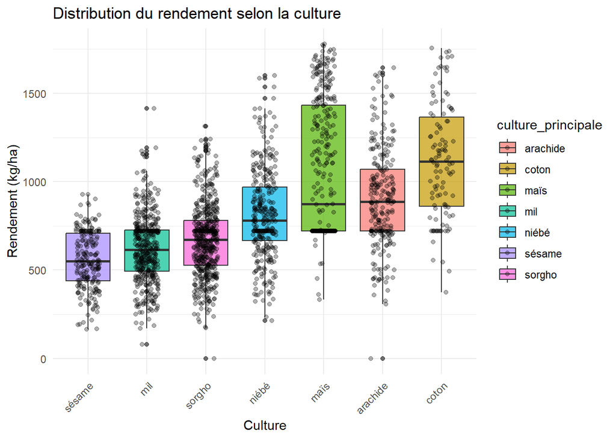

```r
# Visualisation
data_clean %>%
  ggplot(aes(x = reorder(culture_principale, rendement_kg_ha, FUN = median), y = rendement_kg_ha, fill = culture_principale)) +
  geom_boxplot(alpha = 0.7) +
  geom_jitter(width = 0.2, alpha = 0.3) +
  labs(title = "Distribution du rendement selon la culture",
       x = "Culture", y = "Rendement (kg/ha)" ) +
  theme_minimal() + theme(axis.text.x = element_text(angle = 45, hjust = 1))
```

```r
# Resumé
data_clean %>%
  group_by(culture_principale) %>%
  summarise(
    Moyenne = mean(rendement_kg_ha),
    mediane = median(rendement_kg_ha),
    Ecart_type = sd(rendement_kg_ha) %>%
  print()
  )
```

```
## [1] 280.5424
## [1] 323.6177
## [1] 381.567
## [1] 190.0736
## [1] 252.6619
## [1] 204.6727
## [1] 162.113
```

| culture_principale | Moyenne | mediane | Ecart_type |
| --- | --- | --- | --- |
| arachide | 901.9289 | 885.80 | 280.5424 |
| coton | 1119.0200 | 1114.95 | 323.6177 |
| maïs | 1056.4459 | 873.90 | 381.5670 |
| mil | 619.6157 | 614.70 | 190.0736 |
| niébé | 813.7146 | 780.30 | 252.6619 |
| sorgho | 668.1478 | 670.95 | 204.6727 |
| sésame | 557.3146 | 549.80 | 162.1130 |

[output not shown]

7 rows

*Interprétation :*

Les fortes variations d’écart-type et de formes de boîtes valident l’utilisation du test non-parométrique de kruskal-Wallis pour la comparaison des moyennes.

### 5.1.2 4.1.2. Rendement par departement et sexe

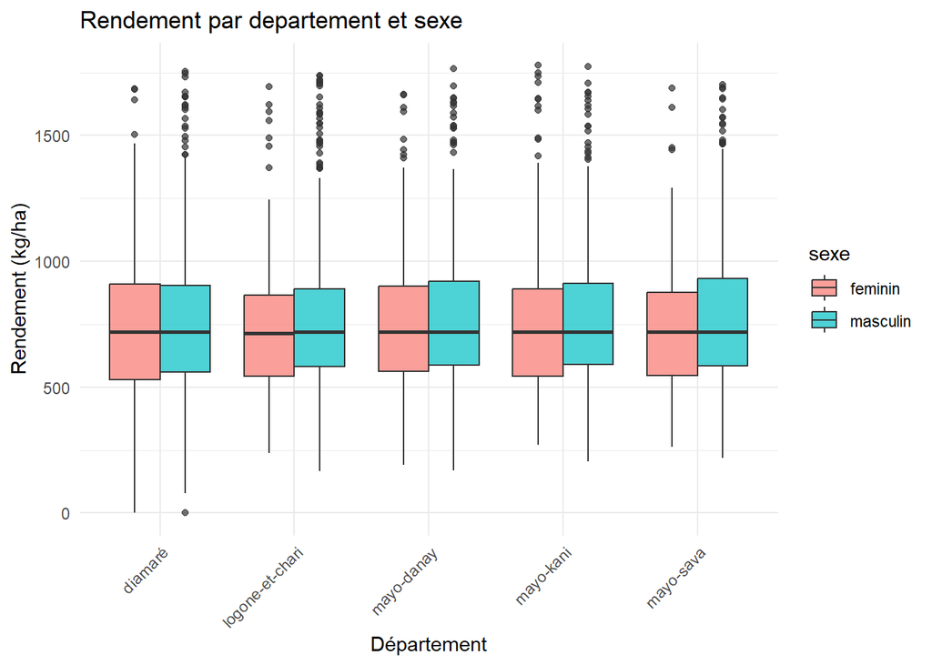

```r
data_clean %>%
  ggplot(aes(x = departement, y = rendement_kg_ha, fill = sexe)) +
  geom_boxplot(alpha = 0.7, position = "dodge") +
  labs(title = "Rendement par departement et sexe",
         x = "Département", y = "Rendement (kg/ha)" ) +
  theme_minimal() + theme(axis.text.x = element_text(angle = 45, hjust = 1))
```

*Interprétation :*

Le graphique en boîte a moustaches croisant le rendement avec le département et le sexe des exploitants révèle une structure de production particulèrement homogène a l’échelle régionale : - Equité des rendements selon le sexe : dans la quasi-totalité des départements, les médianes et les distributions des rendements entre les hommes et les femmes sont quasi identiques. Il n’apparaît pas de disparité visuelle majeure liée au genre sur la productivité brute a l’hectare. - Stabilité inter-département : les niveaux de rendement restent globalement similaires d’un département a un autre, se concentrant majoritairement entre 500 et 1000 kg/ha. Le Logone-et-Chari affiche une dispersion légèrement plus basse pour les deux sexes. - Présence de valeurs atypique(Outliers) : On observe de nombreuses valeurs supérieures atypiques(points isolés s’étendant jusqu’a plus de 1500 kg/ha) dans tous les départements, peu importe le sexe. Elles représentent des exploitations performantes(sûrement dotées d’un meilleur accès aux intrants ou a l’irrigation).

L’alignement presque parfait des boîtes suggère que le test de Wilcoxon pourrait conclure a une absence de différence statistiquement significative entre le rendement des hommes et des femmes sur l’ensemble de l’échantillon.

### 5.1.3 4.1.3. Pluviometrie vs rendement

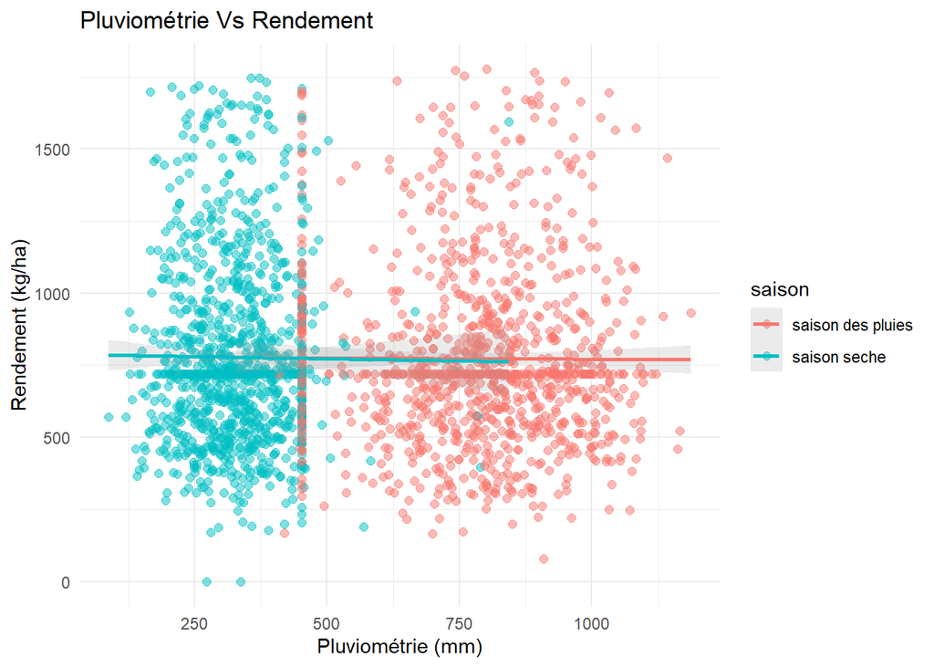

```r
data_clean %>%
  ggplot(aes(x = pluviometrie_mm, y = rendement_kg_ha, color = saison)) +
  geom_point(alpha = 0.5, size = 2) +
  geom_smooth(method = "lm", se = T, alpha = 0.2) +
  labs( title = "Pluviométrie Vs Rendement",
        x= "Pluviométrie (mm)", y = "Rendement (kg/ha)"
        ) +
  theme_minimal()
```

```r
cor_val <-  cor(data_clean$pluviometrie_mm, data_clean$rendement_kg_ha)
cat("Corrélations:", round(cor_val,3), "\n")
```

```
## Corrélations: -0.01
```

*Interprétation :*

Le nuage de points combiné aux droites de régression lineaire permet d’analyser l’impact des précipitations sur la productivité agricole selon la saison : - Séparation nette des saisons : le graphique montre deux clusters distincts de données, la saison seche regroupe des cumuls pluviométriques faibles(inférieurs a 500 mm), tandis que la saison des pluies seconcentre sur des précipitations plus intenses(généralement comprises entre 500 et 1100 mm). - Absence de corrélation linéaire globale : le coefficient de corrélation calculé est extrêmement proche de zéro(-0.01). Visuellement, les droites de tendance pour chaque saison sont parfaitement horizontales et plates. Cela indique que, dans les intervalles observés, les variations de la pluviométrie n’induisent aucune hausse ou baisse linéaire directe du rendement global. - Forte variabilité intra-saisonnière : pour un même niveau de précipitations(par exemple a 300 mm ou a 800 mm), les rendements restent très dispersés, oscillant de moins de 500 kg/ha a plus de 1500 kg/ha.

### 5.1.4 4.1.4. Prévalence de la vulnérabilité par département

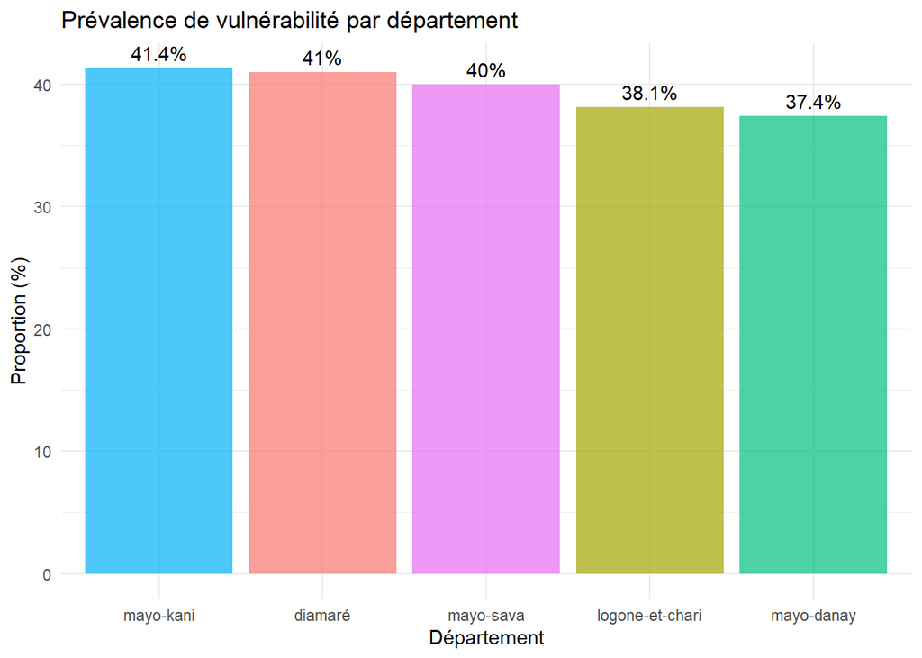

```r
seuil_vul <- median(data_clean$score_securite_alimentaire)

data_clean <- data_clean %>%
  mutate(vulnerable = ifelse(score_securite_alimentaire < seuil_vul, "vulnérable", "non vulnérable"))

data_clean %>%
  count(departement, vulnerable) %>%
  group_by(departement) %>%
  mutate(prop = n / sum(n) * 100) %>%
  filter(vulnerable == "vulnérable") %>%
  ggplot(aes(x = reorder(departement, -prop), y = prop, fill = departement)) +
  geom_col(alpha = 0.7) +
  geom_text(aes(label = paste0(round(prop, 1), "%")), vjust = -0.5) +
  labs(title = "Prévalence de vulnérabilité par département",
       x = "Département", y = "Proportion (%)")+
  theme_minimal() + theme(legend.position = "none")
```

*Interprétation :*

Les écarts entre les pourcentages étants minimes d’un territoire a l’autre, il est fort probables que le futur test d’indépendance du Chi-deux ou les modèles logistiques révèlent une association statistique faible ou non significative entre le département seul et le statut de vulnérabilité, indiquant que ce problème touche uniformément la région.

### 5.1.5 4.1.5. Rendement moyen (département * culture)

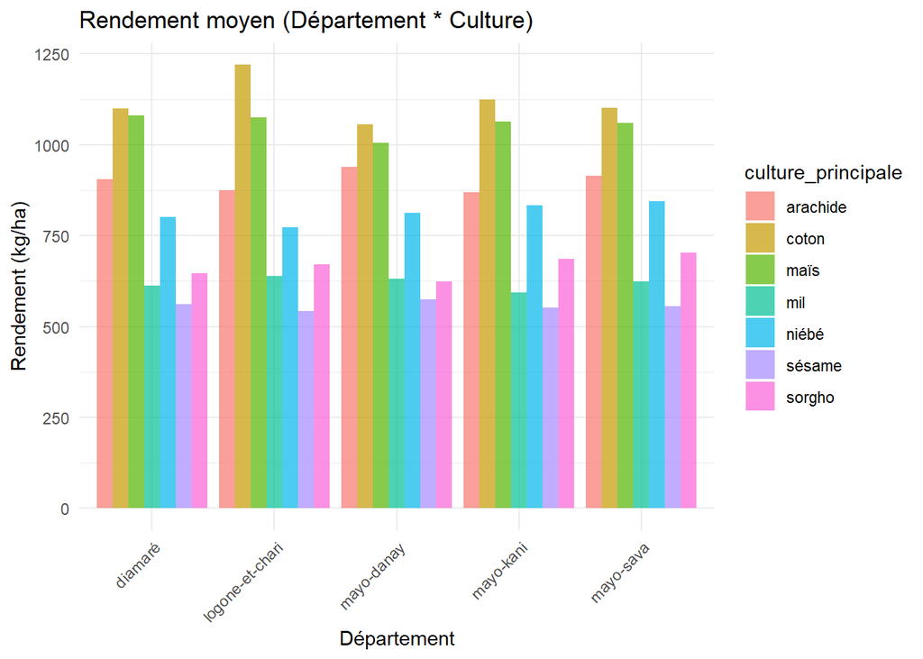

```r
data_clean %>%
  group_by(departement, culture_principale) %>%
  summarise(rdt_moy = mean(rendement_kg_ha), .groups = "drop") %>%
  ggplot(aes(x = departement, y = rdt_moy, fill = culture_principale)) +
  geom_col(position = "dodge", alpha = 0.7) +
  labs (title = "Rendement moyen (Département * Culture)",
        x = "Département", y = "Rendement (kg/ha)") +
  theme_minimal() + theme(axis.text.x = element_text(angle = 45, hjust = 1))
```

*Interprétation :*

Le diagramme a barres juxtaposées permet d’analyser la productivité croisée des différentes cultures au sein de chaque département de la région : - Hiérarchie identique des cultures partout : la structure des rendements reste parfaitement stable d’un térritoire a l’autre. Quelque soit le département, le coton et le mais dominent systématiquement la production avec les barres les plus hautes(dépassant généralement 1000 kg/ha), suivis de l’arachide et du niébé. A l’inverse, le mil, le sésame et le sorgho ferment toujours la marche avec les rendements plus faibles. - Spécificité géographiques mineures : * Le Logone-et-Chari se distingue par le rendement moyen en coton le plus élevé de la région(approchant les 1250 kg/ha) * Les autres départements présentent des profils de récolte quasi superposables pour toutes les spéculations.

Cette forte régularité visuelle indique u effet d’interaction faible ou nul entre le département et le type de culture. Le type de culture reste le facteur prédominant pour expliquer le rendement.

### 5.1.6 4.1.6. Evolution du revenu net par culture

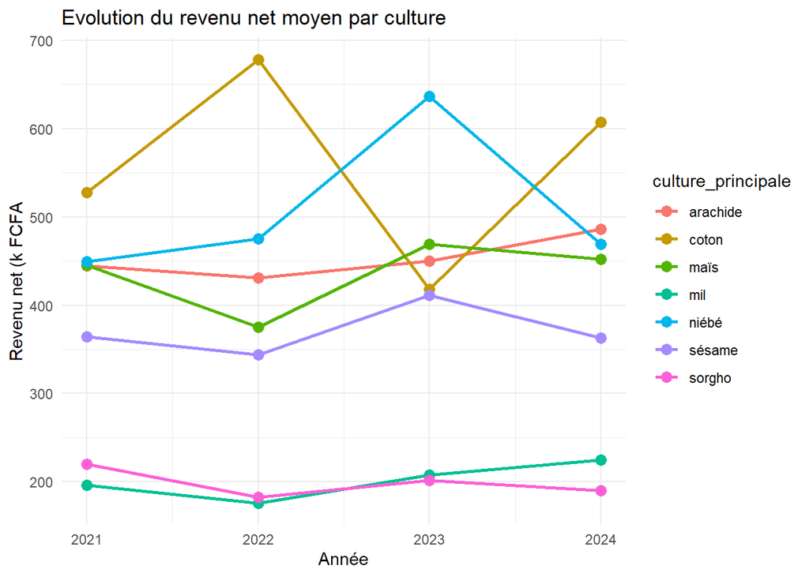

```r
data_clean %>%
  group_by(culture_principale, annee) %>%
  summarise(revenu_moy = mean(revenu_net_k_fcfa), .groups = "drop" ) %>%
  ggplot(aes(x = annee, y = revenu_moy, color = culture_principale)) +
  geom_line(linewidth = 1) +
  geom_point(size = 3) +
  labs(title = "Evolution du revenu net moyen par culture",
       x = "Année", y = "Revenu net (k FCFA") +
  theme_minimal()
```

*Interprétation :*

Le graphique linéaire met en évidens=ce la dynamique temporelle des revenus nets moyens(en milliers de FCFA) générés par chaque culture entre 2021 et 2024 : - Filières a forte volatilité (Coton et Niébé) : * Le coton enregistre une forte hausse jusqu’a un pic en 2022(proche de 680 k FCFA), avant de chutter lourdement en 2023 et de rebondire en 2024. * Le niébé affiche une tendance inverse avec une progression remarquable jusqu’a un pic majeur en 2023(environ 650 k FCFA), avant de redescendre en 2024.Ces fluctuations reflètent la sensibilité de ces cultures de rente aux variations des prix du marché ou aux aléas climatiques annuels. - Stabilité des cultures vivrières (Arachide, Mais et Sésame) : Ces cultures oscillent de manière très stable et linéaire dans une fouchette intermédiaire , cmomprise entre 350 k et 500 k FCFA tout au long de la période. L’arachide montre la trajectoire la plusconstante. - Cultures a faible rentabilité économique (Mil et Sorgho) : Le mil et le sorgho ferment systématiquement la marche avec des revenus nets stagnants et très faibles, se maintenant sous la barre de 250 k FCFA. Bien qu’essentiels très peu de surplus monétaires pour les ménages.

L’évolution temporelle non linéaire de certaines cultures montre que l’annéee de collecte (annee) et son interaction avec le type de culture pourraient représenter des variables explicatives importantes a intégrer dans tes modèles prédictis

## 5.2 4.2. Statistique descriptive

### 5.2.1 4.2.1. Statistique descriptive des variables quantitatives

```r
data_clean %>%
  select(where(is.numeric)) %>%
  pivot_longer(everything()) %>%
  group_by(name) %>%
  summarise(
    N = n(),
    Moyenne = round(mean(value), 2),
    Ecart_type = round(sd(value), 2),
    Médiane = round(median(value), 2),
    Min = round(min(value), 2),
    Max = round(max(value), 2),
    .groups = "drop"
  )
```

| name | N | Moyenne | Ecart_type | Médiane | Min | Max |
| --- | --- | --- | --- | --- | --- | --- |
| age_exploitant | 2215 | 42.01 | 13.64 | 42.0 | 18.0 | 200.00 |
| annee | 2215 | 2022.49 | 1.12 | 2022.0 | 2021.0 | 2024.00 |
| cout_intrants_k_fcfa | 2215 | 20.59 | 16.51 | 16.1 | 0.3 | 120.20 |
| distance_marche_km | 2215 | 11.91 | 11.88 | 8.3 | 0.5 | 107.50 |
| engrais_kg | 2215 | 28.28 | 36.78 | 16.1 | 0.0 | 285.60 |
| experience_annees | 2215 | 12.88 | 7.40 | 13.0 | 0.0 | 39.00 |
| id | 2215 | 1108.00 | 639.56 | 1108.0 | 1.0 | 2215.00 |
| nb_actifs_agricoles | 2215 | 2.48 | 1.27 | 2.0 | 1.0 | 7.00 |
| pesticides_l | 2215 | 1.75 | 2.56 | 0.6 | 0.0 | 17.45 |
| pluviometrie_mm | 2215 | 550.72 | 263.58 | 452.5 | 88.1 | 1187.10 |

[output cut: 11 more lines]

[output not shown]

*Interprétation :*

### 5.2.2 4.2.2. Statistique descriptive des variables qualitatives

```r
print(data_clean %>%
        count(saison) %>%
        mutate(
          Pct = round(n/sum(n)*100, 1)
        ))
```

```
## # A tibble: 2 × 3
##   saison                n   Pct
##   <chr>             <int> <dbl>
## 1 saison des pluies  1090  49.2
## 2 saison seche       1125  50.8
```

```r
print(data_clean %>%
        count(sexe) %>%
        mutate(
          Pct = round(n/sum(n)*100, 1)
        ))
```

```
## # A tibble: 2 × 3
##   sexe         n   Pct
##   <chr>    <int> <dbl>
## 1 feminin    633  28.6
## 2 masculin  1582  71.4
```

```r
print(data_clean %>%
        count(departement) %>%
        mutate(
          Pct = round(n/sum(n)*100, 1)
        ))
```

```
## # A tibble: 5 × 3
##   departement         n   Pct
##   <chr>           <int> <dbl>
## 1 diamaré           439  19.8
## 2 logone-et-chari   438  19.8
## 3 mayo-danay        441  19.9
## 4 mayo-kani         452  20.4
## 5 mayo-sava         445  20.1
```

```r
print(data_clean %>%
        count(culture_principale) %>%
        mutate(
          Pct = round(n/sum(n)*100, 1)
        ))
```

```
## # A tibble: 7 × 3
##   culture_principale     n   Pct
##   <chr>              <int> <dbl>
## 1 arachide             249  11.2
## 2 coton                110   5
## 3 maïs                 333  15
## 4 mil                  447  20.2
## 5 niébé                323  14.6
## 6 sorgho               534  24.1
## 7 sésame               219   9.9
```

```r
cat("\n Contingence Sexe * Accès Crédit : \n")
```

```
##
##  Contingence Sexe * Accès Crédit :
```

```r
print(table(data_clean$sexe, data_clean$acces_credit))
```

```
##
##             non  oui
##   feminin   426  207
##   masculin 1114  468
```

*Interprétation :*

L’analyse des fréquences des variables catégorielles permet de dresser le profil structurel et institutionnel de notre échantillon :

## 5.3 4.3. Test

Les analyses exploratoire ont permis de mettre en évidence plusieurs différences potentielles entre groupes. Afin de déterminer si ces diférences sont statistiquement significatives, des tests inférentiels adaptés a la nature des variables et au respect des hypothèses statistiques sont réalisés.

### 5.3.1 4.2.3. Test de la normalité de Shapiro-Wilk

```r
vars_normality <- c("rendement_kg_ha", "revenu_net_k_fcfa", "pluviometrie_mm")

resultats_shapiro <- map_df(vars_normality, ~{
  test <- shapiro.test(data_clean[[.x]])
  tibble(
    variable = .x,
    Statistique_W = round(test$statistic, 4),
    P_valeur = round(test$p.value, 4),
    Normal = ifelse(test$p.value > 0.05, "Oui", "Non")
  )
})
print(resultats_shapiro)
```

```
## # A tibble: 3 × 4
##   variable          Statistique_W P_valeur Normal
##   <chr>                     <dbl>    <dbl> <chr>
## 1 rendement_kg_ha           0.930        0 Non
## 2 revenu_net_k_fcfa         0.634        0 Non
## 3 pluviometrie_mm           0.918        0 Non
```

*Interprétation des résultats :*

L’hypothèse nulle ($H_0$) du test stipule que la variable suit une loi normale. Si la p-valeur est inférieure au seuil critique de 5 % (0,05), on rejette $H_0$. Le tableau de résultats indique les métriques suivantes :

- Rendement : Statistique_W = 0,9305 ; p-valeur = 0. La distribution n’est pas normale.

-Revenu net : Statistique_W = 0,6335 ; p-valeur = 0. La distribution s’écarte très sévèrement d’une loi normale (ce qui corrobore la présence de fortes inégalités et l’asymétrie observée précédemment).

-Pluviométrie : Statistique_W = 0,9183 ; p-valeur = 0. La distribution n’est pas normale.

Les trois p-valeurs étant strictement inférieures à 0,05, l’hypothèse de normalité est catégoriquement rejetée pour toutes ces variables. Ce constat valide définitivement le recours à des tests non paramétriques (Wilcoxon et Kruskal-Wallis) pour les étapes suivantes de notre analyse descriptive comparative.

### 5.3.2 4.2.4. Test de Wilcoxon : rendement Homme vs Femme

Nous allons procédé au test de Wilcoxon-Mann-Whitney car :

- La section précédente (4.2.3) a démontré de manière catégorique que la variable du rendement (rendement_kg_ha) ne suit pas une loi normale. Le test de Student (t-test), qui est paramétrique, est donc mathématiquement invalidé.
- De plus Nous comparons une variable quantitative (le rendement) entre deux groupes indépendants définis par une variable qualitative binaire (le sexe : Homme vs Femme).Contrairement au test t qui compare les moyennes, le test de Wilcoxon compare la distribution globale et les rangs (ou médianes).

```r
rdt_hommes <- data_clean %>%
  filter(sexe == "masculin") %>%
  pull(rendement_kg_ha)

rdt_femmes <- data_clean %>%
  filter(sexe == "feminin") %>%
  pull(rendement_kg_ha)

test_wilcox <- wilcox.test(rdt_hommes, rdt_femmes)

if (test_wilcox$p.value < 0.05) {
  cat("Différence Significative \n")
} else {
  cat("Pas de différence significative \n")
}
```

```
## Différence Significative
```

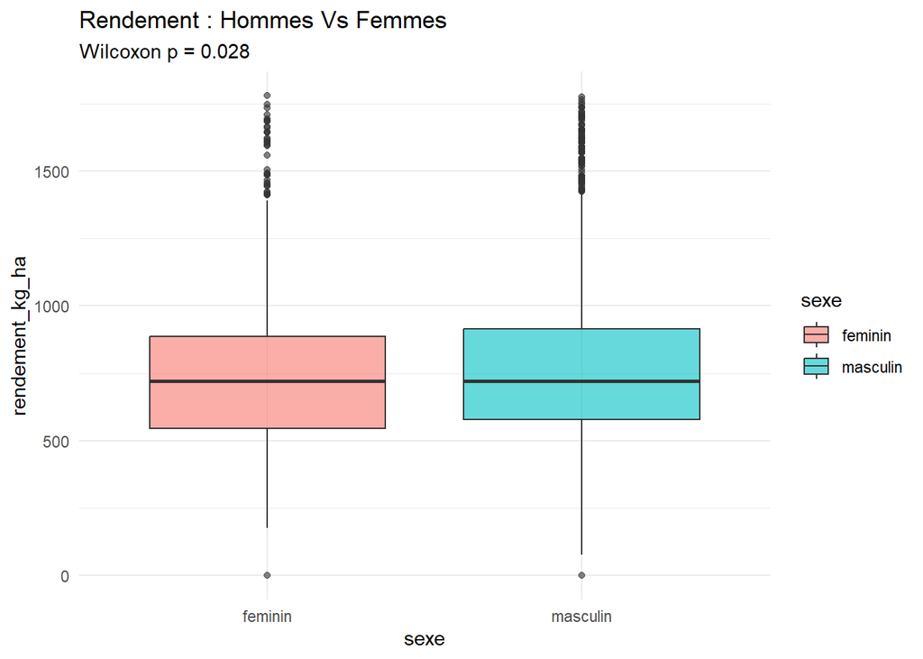

```r
# Graphique

data_clean %>%
  ggplot(aes(x = sexe, y = rendement_kg_ha, fill = sexe)) +
  geom_boxplot(alpha = 0.6) +
  labs(title = "Rendement : Hommes Vs Femmes",
       subtitle = paste("Wilcoxon p =", round(test_wilcox$p.value, 4))) +
  theme_minimal()
```

*Interprétation des résultats :*

### 5.3.3 4.2.5. Test de Kruskal-Wallis : rendement selon le département

```r
test_kruskal <- kruskal.test(rendement_kg_ha ~ departement, data = data_clean)

if (test_kruskal$p.value < 0.05) {
  cat("Rendement différent significativement par département \n")
} else {
  cat("Pas de différence significative \n")
}
```

```
## Pas de différence significative
```

```r
# Stats par département

data_clean %>%
  group_by(departement) %>%
  summarise(
    N = n(),
    Rendement_moyen = round(mean(rendement_kg_ha), 2),
    Médiane = round(median(rendement_kg_ha), 2)
  ) %>%
  print()
```

```
## # A tibble: 5 × 4
##   departement         N Rendement_moyen Médiane
##   <chr>           <int>           <dbl>   <dbl>
## 1 diamaré           439            766.    720.
## 2 logone-et-chari   438            776.    720.
## 3 mayo-danay        441            776.    720.
## 4 mayo-kani         452            787.    720.
## 5 mayo-sava         445            773.    720.
```

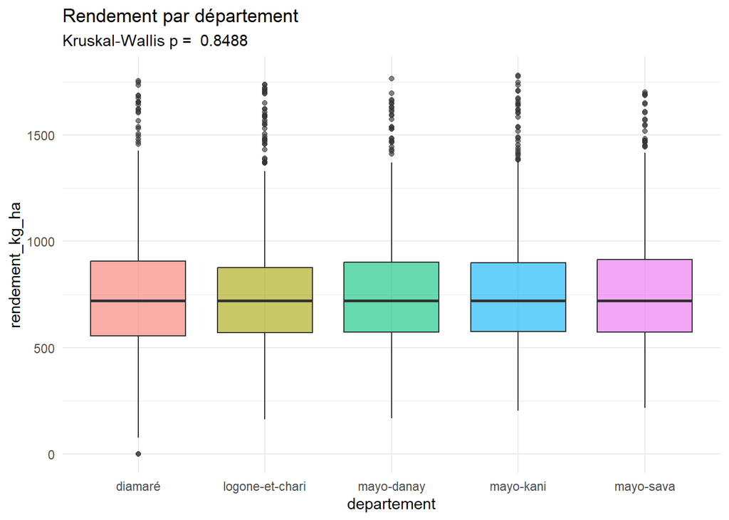

```r
# Graphique

data_clean %>%
  ggplot(aes(x = departement, y = rendement_kg_ha, fill = departement)) +
  geom_boxplot(alpha = 0.6) +
  labs(title = "Rendement par département",
       subtitle = paste("Kruskal-Wallis p = ", round(test_kruskal$p.value, 4))) +
  theme_minimal() + theme(legend.position = "none")
```

### 5.3.4 4.2.6. Test du Chi-deux : accès au crédit * vulnérabilité alimentaire

Le test du Chi-deux d’indépendance est le test de référence incontournable ici pour une raison méthodologique simple :

- Contrairement aux sections précédentes qui comparaient une variable quantitative à une variable qualitative, nous cherchons ici à analyser la relation entre deux variables strictement qualitatives et catégorielles : l’accès au crédit et le statut de vulnérabilité du ménage. On ne peut utiliser ni un test de Wilcoxon, ni un Kruskal-Wallis, ni un test t sur des proportions brutes. Le test du Chi-deux permet de comparer mathématiquement les effectifs observés dans notre table de contingence aux effectifs théoriques attendus sous l’hypothèse d’une indépendance totale, afin de déterminer si ces deux dimensions s’influencent mutuellement.

```r
contingence <- table(data_clean$acces_credit, data_clean$vulnerable)
test_chi2 <- chisq.test(contingence)

print(contingence)
```

```
##
##       non vulnérable vulnérable
##   non            946        594
##   oui            392        283
```

```r
if(test_chi2$p.value < 0.05 ) {
  cat("Accès crédit et vulnérabilité sont liés \n")
} else {
  cat(" Pas de relation significative \n")
}
```

```
##  Pas de relation significative
```

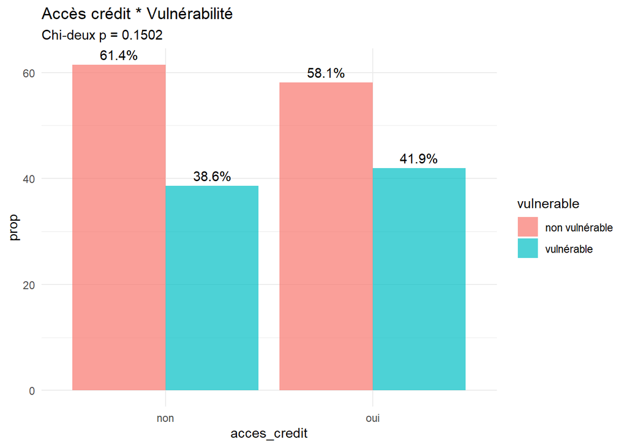

```r
# Graphique

data_clean %>%
  count(acces_credit, vulnerable) %>%
  group_by(acces_credit) %>%
  mutate(prop = n/ sum(n)*100) %>%
  ggplot(aes(x = acces_credit, y = prop, fill = vulnerable))+
  geom_col(position = "dodge", alpha = 0.7) +
  geom_text(aes(label = paste0(round(prop, 1), "%")),
            position = position_dodge(width = 0.9), vjust = -0.5) +
  labs(title = "Accès crédit * Vulnérabilité",
       subtitle = paste("Chi-deux p =", round(test_chi2$p.value, 4))) +
  theme_minimal()
```

*Interprétation des résultats :*

L’hypothèse nulle ($H_0$) stipule que l’accès au crédit et le statut de vulnérabilité sont totalement indépendants (le fait d’obtenir un financement n’influence pas et n’est pas influencé par le niveau de vulnérabilité du ménage). D’après le graphique en barres juxtaposées :

- La p-valeur obtenue est de 0,1502 (affichée en haut du graphique Chi-deux p = 0.1502).
- Décision statistique : La p-valeur étant supérieure au seuil critique de 5 % (0,1502 > 0,05), on ne peut pas rejeter l’hypothèse nulle $H_0$. La relation entre l’accès au crédit et la vulnérabilité n’est pas statistiquement significative.
- Analyse visuelle des proportions :
  - Chez les ménages sans accès au crédit (non), 38,6 % sont jugés vulnérables contre 61,4 % non vulnérables.
  - Chez les ménages ayant accès au crédit (oui), la proportion de personnes vulnérables grimpe légèrement à 41,9 % (contre 58,1 % non vulnérables).
  - Bien qu’on observe visuellement un très léger écart de proportions (~3,3 % d’écart), le test du Chi-deux démontre que cette fluctuation est trop faible au regard de la taille de l’échantillon pour être attribuée à un véritable lien de cause à effet. Elle relève purement du hasard de l’échantillonnage.

L’accès au crédit n’apparaît pas corrélé de façon significative à l’état de vulnérabilité des producteurs dans notre zone d’étude. Cela peut traduire le fait que le crédit agricole est soit alloué de manière uniforme sans ciblage spécifique, soit que ses effets n’ont pas encore modifié structurellement le profil de vulnérabilité économique à court terme.

# 6 5. Regression et modelisation

### 6.0.1 5.1. Prédiction du rendement (Régression linéaire multiple)

#### 6.0.1.1 5.1.1. Construction du modèle

Pour identifier et quantifier les déterminants structurels du rendement agricole dans la région, nous allons estimé un modèle de régression linéaire par la méthode des Moindres Carrés Ordinaires (MCO). La variable dépendante est le rendement (rendement_kg_ha).

```r
# modele pour prédire le rendement
modele_lin <- lm(
  rendement_kg_ha ~ pluviometrie_mm + superficie_ha + engrais_kg + sexe +
    age_exploitant + departement,
  data = data_clean
)

summary(modele_lin)
```

```
##
## Call:
## lm(formula = rendement_kg_ha ~ pluviometrie_mm + superficie_ha +
##     engrais_kg + sexe + age_exploitant + departement, data = data_clean)
##
## Residuals:
##     Min      1Q  Median      3Q     Max
## -811.78 -204.47  -49.71  120.96 1021.71
##
## Coefficients:
##                              Estimate Std. Error t value Pr(>|t|)
## (Intercept)                698.435758  31.628095  22.083  < 2e-16 ***
## pluviometrie_mm             -0.005422   0.025543  -0.212   0.8319
## superficie_ha               -0.076811   0.310479  -0.247   0.8046
## engrais_kg                   1.098921   0.179063   6.137 9.94e-10 ***
## sexemasculin                31.112823  14.565308   2.136   0.0328 *
## age_exploitant               0.409996   0.482262   0.850   0.3953
## departementlogone-et-chari   7.066481  21.086696   0.335   0.7376
## departementmayo-danay       11.389615  20.873167   0.546   0.5854
## departementmayo-kani        22.645563  20.741973   1.092   0.2751
## departementmayo-sava         7.932541  20.993991   0.378   0.7056
## ---
## Signif. codes:  0 '***' 0.001 '**' 0.01 '*' 0.05 '.' 0.1 ' ' 1
##
## Residual standard error: 309.3 on 2205 degrees of freedom
## Multiple R-squared:  0.01956,    Adjusted R-squared:  0.01556
## F-statistic: 4.888 on 9 and 2205 DF,  p-value: 1.654e-06
```

*Observation du modele :*

- Qualité globale du modèle et pertinence
  - Significativité globale : Le modèle est globalement très significatif comme l’indique la p-valeur de la statistique F (p = 1,654 * 10^(-6)), bien inférieure au seuil de 1 %. Les variables explicatives choisies apportent une information réelle pour expliquer les variations du rendement.
  - Le coefficient de détermination ajusté (R^2- ajusté = 0,01556) indique que le modèle n’explique que 1,56 % de la variance du rendement. Il indique que la majeure partie de la productivité dépend d’autres facteurs non capturés ici.
- Interprétation des coefficients (Toutes choses égales par ailleurs)

  Les variables explicatives se divisent clairement entre facteurs hautement critiques et facteurs statistiquement neutres :
  - L’engrais–Un levier de productivité majeur : Cette variable affiche un effet positif et hautement significatif au seuil de 0,1 % (p = 9,94 * 10^(-10)). L’apport d’un kilogramme d’engrais supplémentaire augmente le rendement moyen de 1,10 kg/ha. L’intensification par les intrants chimiques reste un pilier central de la performance agricole locale.
  - Le sexe (sexemasculin) – Un avantage aux parcelles masculines : Le genre du chef d’exploitation exerce une influence significative au seuil de 5 % (p = 0,0328). Les exploitations dirigées par des hommes enregistrent en moyenne un rendement supérieur de 31,11 kg/ha par rapport à celles dirigées par des femmes.

Étant donné le faible R^2 et l’absence d’effet linéaire de la pluviométrie, il serait judicieux d’explorer l’introduction d’interactions (comme l’interaction entre l’année ou le type de culture et les variables climatiques) pour affiner la puissance prédictive de ton modèle.

#### 6.0.1.2 5.1.2. Evaluation et diagnostic

Pour vérifier la validité des hypothèses des Moindres Carrés Ordinaires (MCO), nous analysons les résidus.

```r
library(broom)

# Résumé des coefficients

tidy(modele_lin) %>%
  filter(p.value < 0.05)
```

| term | estimate | std.error | statistic | p.value |
| --- | --- | --- | --- | --- |
| (Intercept) | 698.435758 | 31.6280951 | 22.082764 | 8.614678e-98 |
| engrais_kg | 1.098921 | 0.1790626 | 6.137080 | 9.936884e-10 |
| sexemasculin | 31.112823 | 14.5653081 | 2.136091 | 3.278184e-02 |

[output not shown]

3 rows

```r
# R^2 et RME

rsq <- summary(modele_lin)$r.squared
rmse <- sqrt(mean(residuals(modele_lin)^2))

cat("R^2 :", round(rsq, 4), "\n")
```

```
## R^2 : 0.0196
```

```r
cat("RMSE : ", round(rmse, 2), "kg/ha \n")
```

```
## RMSE :  308.6 kg/ha
```

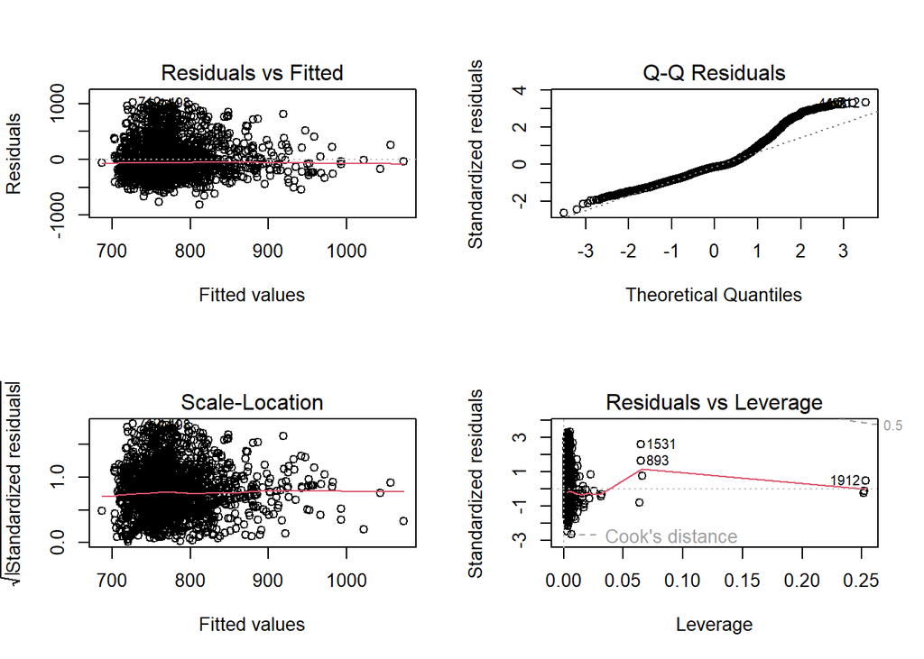

```r
# Diagnostic graphique
par(mfrow = c(2, 2))
plot(modele_lin)
```

```r
par(mfrow = c(1, 1))
```

*Observation des résultats :*

- Residuals vs Fitted (Linéarité) : La ligne rouge horizontale reste globalement plate et centrée autour de zéro. Cela confirme que la relation de linéarité entre les variables explicatives et le rendement est globalement respectée.
- Normal Q-Q (Normalité des résidus) : Les points s’écartent de la ligne droite diagonale aux deux extrémités . Cela indique que les résidus ne suivent pas parfaitement une loi normale et présentent des queues de distribution lourdes, ce qui fait écho à la non-normalité observée lors du test de Shapiro-Wilk.
- Scale-Location (Homoscédasticité) : La ligne rouge est relativement droite et l’étalement des points est homogène le long des valeurs ajustées. L’hypothèse de variance constante des résidus (homoscédasticité) est donc globalement acceptable.
- Residuals vs Leverage (Points influents) : Aucun point n’apparaît en dehors des limites de la distance de Cook (matérialisée par des lignes pointillées rouges souvent invisibles ou très éloignées ici). Aucune observation aberrante n’exerce d’influence excessive ou disproportionnée sur l’estimation de tes coefficients.

*Verdict :* Malgré un léger défaut de normalité des résidus (courant sur de grands échantillons réels), les conditions d’application du modèle linéaire restent statistiquement acceptables pour valider tes conclusions économiques.

#### 6.0.1.3 5.1.3. Prédictions Vs Réalité

Nous allons confronter visuellement les valeurs réelles du rendement aux valeurs prédites par notre modèle linéaire

```r
library(modelr)
```

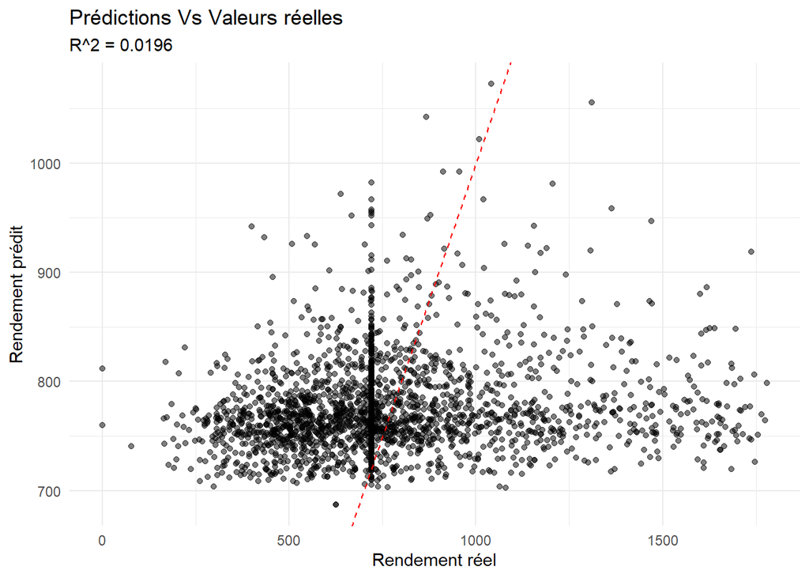

```r
data_pred <- data_clean %>%
  add_predictions(modele_lin) %>%
  add_residuals(modele_lin)

# Graphique
 data_pred %>%
   ggplot(aes(x = rendement_kg_ha, y = pred)) +
   geom_point(alpha = 0.5) +
   geom_abline(slope = 1, intercept = 0, color = "red", linetype = "dashed") +
   labs(title = "Prédictions Vs Valeurs réelles",
        x = "Rendement réel", y = "Rendement prédit",
        subtitle = paste("R^2 =", round(rsq, 4))) +
   theme_minimal()
```

*Observation des résultats :*

- La majorité des points forment un nuage dense étalé horizontalement, principalement concentré entre 600 et 900 kg/ha pour le rendement prédit, alors que les rendements réels s’étendent de 0 à près de 1 800 kg/ha.
- Les points s’éloignent fortement de la droite de référence diagonale en pointillés (la droite y = x où la prédiction égalerait parfaitement la réalité). Le modèle a une nette tendance à surestimer les faibles rendements réels et à sous-estimer les rendements réels les plus élevés.
- Confirmation du faible pouvoir prédictif : Cette faible adéquation visuelle illustre concrètement la valeur du coefficient de détermination (R^2 = 0,0196, soit 1,96 %). Le modèle capte la tendance centrale globale grâce aux variables significatives (engrais, sexe), mais ne parvient pas à modéliser la forte dispersion et la variabilité des situations réelles des ménages agricoles.

### 6.0.2 5.2. Prédiction de la vulnérabilité alimentaire

#### 6.0.2.1 5.2.1. Construction du modèle

Pour analyser les facteurs déterminant la vulnérabilité alimentaire, nous avons estimé un modèle de régression logistique. La modalité prédite est le fait d’être un ménage vulnérable.

```r
# Conversion
data_clean$vulnerable <- factor(
  data_clean$vulnerable,
  levels = c("non vulnérable", "vulnérable")
)

# Modele
modele_log <- glm(
  vulnerable ~ revenu_net_k_fcfa + acces_credit + acces_marche +
    age_exploitant + taille_menage,
  family = binomial(link = "logit"),
  data = data_clean
)

summary(modele_log)
```

```
##
## Call:
## glm(formula = vulnerable ~ revenu_net_k_fcfa + acces_credit +
##     acces_marche + age_exploitant + taille_menage, family = binomial(link = "logit"),
##     data = data_clean)
##
## Coefficients:
##                              Estimate Std. Error z value Pr(>|z|)
## (Intercept)                -0.3483503  0.1884597  -1.848   0.0645 .
## revenu_net_k_fcfa           0.0001579  0.0001152   1.370   0.1706
## acces_creditoui             0.1446304  0.0941811   1.536   0.1246
## acces_marcheroute bitumée  -0.0760159  0.1160039  -0.655   0.5123
## acces_marchesentier         0.1294305  0.1080536   1.198   0.2310
## acces_marchevoie navigable  0.1974138  0.1498952   1.317   0.1878
## age_exploitant             -0.0044367  0.0032903  -1.348   0.1775
## taille_menage              -0.0039451  0.0150706  -0.262   0.7935
## ---
## Signif. codes:  0 '***' 0.001 '**' 0.01 '*' 0.05 '.' 0.1 ' ' 1
##
## (Dispersion parameter for binomial family taken to be 1)
##
##     Null deviance: 2974.0  on 2214  degrees of freedom
## Residual deviance: 2963.5  on 2207  degrees of freedom
## AIC: 2979.5
##
## Number of Fisher Scoring iterations: 4
```

*Observation du modele :*

#### 6.0.2.2 5.2.2 Odds Ratios

```r
tidy(modele_log) %>%
  mutate(
    Odds_Ratio = exp(estimate),
    Pct_change = (Odds_Ratio - 1) * 100
  ) %>%
  filter(p.value < 0.05) %>%
  select(term, Odds_Ratio, Pct_change, p.value)
```

| term | Odds_Ratio | Pct_change | p.value |
| --- | --- | --- | --- |

[output not shown]

0 rows

#### 6.0.2.3 5.2.3 Performance du modèle

```r
library(pROC)
# Prédiction de probabilités
data_clean$prob_vuln <- predict(modele_log,
                                newdata = data_clean,
                                type = "response")

# Conserver uniquement les observations ayant une prédiction
data_eval <- data_clean %>%
  filter(!is.na(data_clean$prob_vuln))

# Prédictions des classes(seuil = 0.5)
pred_class <- ifelse(data_eval$prob_vuln > 0.5, "vulnérable", "non vulnérable")

# Matrice de confusion
confusion <- table(Réel = data_eval$vulnerable, Prédit = pred_class)
print(confusion)
```

```
##                 Prédit
## Réel            non vulnérable vulnérable
##   non vulnérable           1336          2
##   vulnérable                874          3
```

```r
# Accuracy
accuracy <- sum(diag(confusion)) / sum(confusion)
cat("Accuracy :", round(accuracy, 4), "\n")
```

```
## Accuracy : 0.6045
```

```r
# AUC (ROC)

roc_obj <- roc(
  response = data_eval$vulnerable,
  predictor = data_eval$prob_vuln)
cat("AUC :", round(auc(roc_obj), 4), "\n")
```

```
## AUC : 0.5351
```

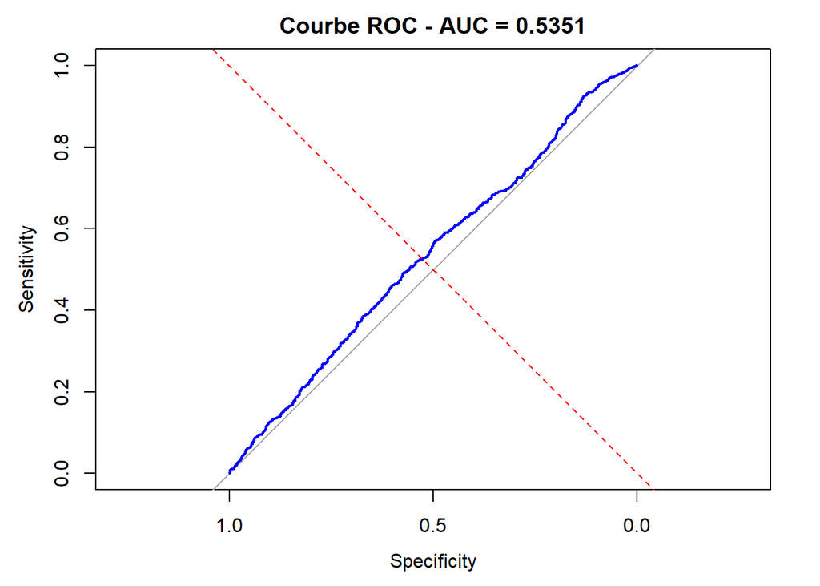

```r
# Courbe ROC
plot(
  roc_obj,
  main = paste("Courbe ROC - AUC =",
               round(auc(roc_obj), 4)),
  col = "blue",
  lwd = 2
  )
abline(a = 0, b = 1, lty = 2, col = "red")
```

*Observation des résultats :*

#### 6.0.2.4 5.2.4 Distribution des probabilités

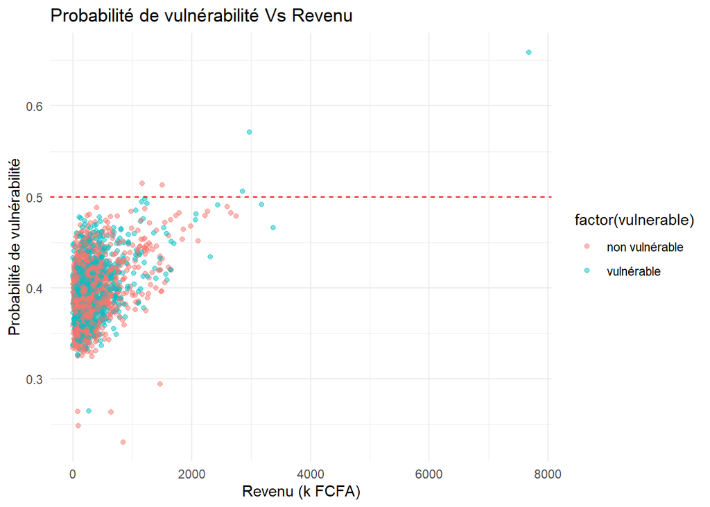

```r
data_clean %>%
  ggplot(aes(x = revenu_net_k_fcfa, y = prob_vuln, color = factor(vulnerable)))+
  geom_point(alpha = 0.5) +
  geom_hline(yintercept = 0.5, linetype = "dashed", color = "red") +
  labs(title = "Probabilité de vulnérabilité Vs Revenu",
       x = "Revenu (k FCFA)", y = "Probabilité de vulnérabilité") +
  theme_minimal()
```

# 7 6. Data science

## 7.1 6.1. Préparation des features et normalisation

### 7.1.1 6.1.1. Sélection des features

```r
library(recipes)
library(caret)
library(randomForest)
# Sélectionner les features pertinentes
data_ml <- data_clean %>%
  select(
    # Variable cible
    rendement_kg_ha,
    # Features numériques
    pluviometrie_mm,
    temperature_moy_c,
    superficie_ha,
    engrais_kg,
    pesticides_l,
    semences_kg,
    age_exploitant,
    taille_menage,
    revenu_brut_k_fcfa,
    cout_intrants_k_fcfa,
    # Features catégoriques
    sexe,
    departement,
    culture_principale,
    saison
  ) %>%
  drop_na()  # Supprimer les NA

cat("Dimensions après sélection :", nrow(data_ml), "×", ncol(data_ml), "\n")
```

```
## Dimensions après sélection : 2215 × 15
```

### 7.1.2 6.1.2. Normalisation des variables numériques

```r
# Créer une recette de normalisation
recette <- recipe(rendement_kg_ha ~ ., data = data_ml) %>%
  step_dummy(all_nominal_predictors()) %>%
  step_normalize(all_numeric_predictors())

# Appliquer la recette
data_prep <- prep(recette, data = data_ml)
data_normalized <- bake(data_prep, new_data = data_ml)


# Vérifier : moyenne ≈ 0, écart-type ≈ 1

data_normalized %>%
  select(where(is.numeric)) %>%
  summarise(across(everything(), ~round(mean(.), 4))) %>%
  print()
```

```
## # A tibble: 1 × 23
##   pluviometrie_mm temperature_moy_c superficie_ha engrais_kg pesticides_l
##             <dbl>             <dbl>         <dbl>      <dbl>        <dbl>
## 1               0                 0             0          0            0
## # ℹ 18 more variables: semences_kg <dbl>, age_exploitant <dbl>,
## #   taille_menage <dbl>, revenu_brut_k_fcfa <dbl>, cout_intrants_k_fcfa <dbl>,
## #   rendement_kg_ha <dbl>, sexe_masculin <dbl>,
## #   departement_logone.et.chari <dbl>, departement_mayo.danay <dbl>,
## #   departement_mayo.kani <dbl>, departement_mayo.sava <dbl>,
## #   culture_principale_coton <dbl>, culture_principale_maïs <dbl>,
## #   culture_principale_mil <dbl>, culture_principale_niébé <dbl>, …
```

```r
data_normalized %>%
  select(where(is.numeric)) %>%
  summarise(across(everything(), ~round(sd(.), 4))) %>%
  print()
```

```
## # A tibble: 1 × 23
##   pluviometrie_mm temperature_moy_c superficie_ha engrais_kg pesticides_l
##             <dbl>             <dbl>         <dbl>      <dbl>        <dbl>
## 1               1                 1             1          1            1
## # ℹ 18 more variables: semences_kg <dbl>, age_exploitant <dbl>,
## #   taille_menage <dbl>, revenu_brut_k_fcfa <dbl>, cout_intrants_k_fcfa <dbl>,
## #   rendement_kg_ha <dbl>, sexe_masculin <dbl>,
## #   departement_logone.et.chari <dbl>, departement_mayo.danay <dbl>,
## #   departement_mayo.kani <dbl>, departement_mayo.sava <dbl>,
## #   culture_principale_coton <dbl>, culture_principale_maïs <dbl>,
## #   culture_principale_mil <dbl>, culture_principale_niébé <dbl>, …
```

*Observation :* La normalisation standardise chaque variable numériques (moyenne ≈ 0, écart-type ≈ 1). Les variables catégoriques sont converties en variables dummy binaires. Cette étape est cruciale pour les algorithmes sensibles à l’échelle (Random Forest, GBM).

## 7.2 6.2. Division de la base en train/test (80%/20%)

```r
set.seed(123)  # Pour la reproductibilité

# Créer l'index de split stratifiée
train_index <- createDataPartition(
  data_normalized$rendement_kg_ha,
  p = 0.8,
  list = FALSE
)

# Diviser les données
train_data <- data_normalized[train_index, ]
test_data <- data_normalized[-train_index, ]

cat("Taille TRAIN :", nrow(train_data), "obs (80%)\n")
```

```
## Taille TRAIN : 1775 obs (80%)
```

```r
cat("Taille TEST  :", nrow(test_data), "obs (20%)\n")
```

```
## Taille TEST  : 440 obs (20%)
```

```r
# Comparer les distributions
cat("\nStatistiques TRAIN vs TEST\n")
```

```
##
## Statistiques TRAIN vs TEST
```

```r
cat("RENDEMENT TRAIN :\n")
```

```
## RENDEMENT TRAIN :
```

```r
cat("  Moyenne :", round(mean(train_data$rendement_kg_ha), 2), "kg/ha\n")
```

```
##   Moyenne : 772.96 kg/ha
```

```r
cat("  Médiane :", round(median(train_data$rendement_kg_ha), 2), "kg/ha\n")
```

```
##   Médiane : 720.2 kg/ha
```

```r
cat("  Écart-type :", round(sd(train_data$rendement_kg_ha), 2), "kg/ha\n")
```

```
##   Écart-type : 308.94 kg/ha
```

```r
cat("\nRENDEMENT TEST :\n")
```

```
##
## RENDEMENT TEST :
```

```r
cat("  Moyenne :", round(mean(test_data$rendement_kg_ha), 2), "kg/ha\n")
```

```
##   Moyenne : 786.6 kg/ha
```

```r
cat("  Médiane :", round(median(test_data$rendement_kg_ha), 2), "kg/ha\n")
```

```
##   Médiane : 720.2 kg/ha
```

```r
cat("  Écart-type :", round(sd(test_data$rendement_kg_ha), 2), "kg/ha\n")
```

```
##   Écart-type : 322.9 kg/ha
```

*Observation :* La division stratifiée garantit une répartition équilibrée de la variable cible entre train et test. Les statistiques descriptives du rendement sont comparables entre les deux ensembles, validant la qualité du split.

## 7.3 6.3. Entrainement et comparaison de modèles

### 7.3.1 6.3.1. Modèle 1 : Régression Linéaire (OLS)

```r
# Entraîner le modèle linéaire
model_lm <- lm(rendement_kg_ha ~ ., data = train_data)

summary_lm <- summary(model_lm)

cat("MODÈLE 1 : RÉGRESSION LINÉAIRE (OLS)\n")
```

```
## MODÈLE 1 : RÉGRESSION LINÉAIRE (OLS)
```

```r
cat("R² train :", round(summary_lm$r.squared, 4), "\n")
```

```
## R² train : 0.3828
```

```r
cat("R² ajusté :", round(summary_lm$adj.r.squared, 4), "\n")
```

```
## R² ajusté : 0.3751
```

```r
# Variables significatives
sig_vars <- tidy(model_lm) %>% filter(p.value < 0.05)
cat("Nombre de variables significatives (p < 0.05) :", nrow(sig_vars), "\n")
```

```
## Nombre de variables significatives (p < 0.05) : 10
```

```r
cat("\nVariables significatives :\n")
```

```
##
## Variables significatives :
```

```r
print(sig_vars %>% select(term, estimate, p.value) %>% head(10))
```

```
## # A tibble: 10 × 3
##    term                      estimate  p.value
##    <chr>                        <dbl>    <dbl>
##  1 (Intercept)                  775.  0
##  2 revenu_brut_k_fcfa            50.2 1.48e-15
##  3 sexe_masculin                 15.5 7.69e- 3
##  4 departement_mayo.sava         17.8 4.81e- 2
##  5 culture_principale_coton      49.6 2.10e-13
##  6 culture_principale_maïs       61.2 3.29e-13
##  7 culture_principale_mil       -93.6 5.62e-25
##  8 culture_principale_niébé     -29.3 3.54e- 4
##  9 culture_principale_sésame    -94.3 1.01e-33
## 10 culture_principale_sorgho    -81.4 3.13e-18
```

*Observation :* Le modèle OLS capture la relation linéaire entre les features et le rendement. La normalisation préalable permet une comparaison directe des coefficients.

### 7.3.2 6.3.2. Modèle 2 : Random Forest

```r
# Entraîner le Random Forest
model_rf <- randomForest(
  rendement_kg_ha ~ .,
  data = train_data,
  ntree = 100,
  mtry = sqrt(ncol(train_data) - 1),  # Règle de thumb pour la régression
  importance = TRUE,
  verbose = FALSE
)

cat("\nMODÈLE 2 : RANDOM FOREST\n")
```

```
##
## MODÈLE 2 : RANDOM FOREST
```

```r
print(model_rf)
```

```
##
## Call:
##  randomForest(formula = rendement_kg_ha ~ ., data = train_data,      ntree = 100, mtry = sqrt(ncol(train_data) - 1), importance = TRUE,      verbose = FALSE)
##                Type of random forest: regression
##                      Number of trees: 100
## No. of variables tried at each split: 5
##
##           Mean of squared residuals: 49465.27
##                     % Var explained: 48.14
```

```r
# Importance des variables (Top 10)
cat("\n\nTop 10 variables par importance :\n")
```

```
##
##
## Top 10 variables par importance :
```

```r
importance_df <- data.frame(
  Variable = rownames(importance(model_rf)),
  Importance = importance(model_rf)[, 1]
) %>%
  arrange(desc(Importance)) %>%
  head(10)

print(importance_df)
```

```
##                                            Variable Importance
## revenu_brut_k_fcfa               revenu_brut_k_fcfa  23.532229
## culture_principale_sésame culture_principale_sésame  20.603785
## superficie_ha                         superficie_ha  18.313854
## culture_principale_maïs     culture_principale_maïs  16.135133
## culture_principale_coton   culture_principale_coton  12.975361
## culture_principale_mil       culture_principale_mil   8.292895
## culture_principale_sorgho culture_principale_sorgho   8.255172
## culture_principale_niébé   culture_principale_niébé   7.039016
## engrais_kg                               engrais_kg   6.773028
## cout_intrants_k_fcfa           cout_intrants_k_fcfa   6.002805
```

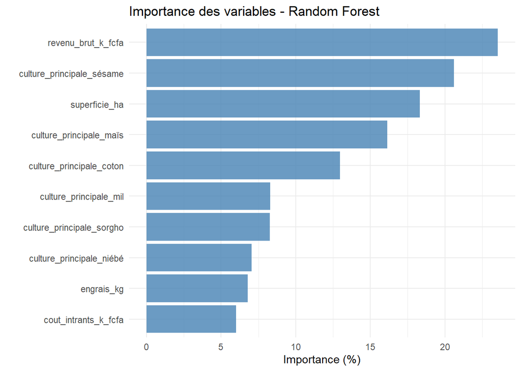

```r
# Visualiser l'importance
var_importance_plot <- importance_df %>%
  ggplot(aes(x = reorder(Variable, Importance), y = Importance)) +
  geom_col(fill = "steelblue", alpha = 0.8) +
  coord_flip() +
  labs(
    title = "Importance des variables - Random Forest",
    x = "",
    y = "Importance (%)"
  ) +
  theme_minimal()

print(var_importance_plot)
```

*Observation :* Le Random Forest capture les relations non-linéaires et les interactions entre variables. L’importance permet d’identifier les variables clés pour la prédiction du rendement.

### 7.3.3 6.3.3. Modèle 3 : Gradient Boosting (GBM)

```r
library(gbm)
# Entraîner le GBM
model_gbm <- gbm(
  rendement_kg_ha ~ .,
  data = train_data,
  distribution = "gaussian",
  n.trees = 150,
  shrinkage = 0.1,
  interaction.depth = 3,
  cv.folds = 5,
  verbose = FALSE
)

cat("\nMODÈLE 3 : GRADIENT BOOSTING (GBM)\n")
```

```
##
## MODÈLE 3 : GRADIENT BOOSTING (GBM)
```

```r
cat("Nombre d'arbres :", model_gbm$n.trees, "\n")
```

```
## Nombre d'arbres : 150
```

```r
cat("Profondeur d'interaction :", model_gbm$interaction.depth, "\n")
```

```
## Profondeur d'interaction : 3
```

```r
# MSE train vs CV
cat("\nPerformance :\n")
```

```
##
## Performance :
```

```r
best_iter <- gbm.perf(model_gbm, plot.it = FALSE, method = "cv")
cat("Meilleure itération (CV) :", best_iter, "\n")
```

```
## Meilleure itération (CV) : 115
```

*Observation :* Le Gradient Boosting combine plusieurs arbres faibles pour créer un prédicteur fort. La validation croisée intégrée aide à éviter le surapprentissage.

## 7.4 6.4. Evaluation sur le data test

### 7.4.1 6.4.1. Prédictions

```r
# Effectuer les prédictions sur l'ensemble TEST
pred_lm <- predict(model_lm, newdata = test_data)
pred_rf <- predict(model_rf, newdata = test_data)
pred_gbm <- predict(model_gbm, newdata = test_data, n.trees = best_iter)

cat("Prédictions effectuées sur test (n =", nrow(test_data), ")\n")
```

```
## Prédictions effectuées sur test (n = 440 )
```

### 7.4.2 6.4.2. Calcul des métriques d’évaluation

```r
# Fonction pour calculer les métriques
calculate_metrics <- function(actual, predicted, model_name) {
  rmse <- sqrt(mean((actual - predicted)^2))
  mae <- mean(abs(actual - predicted))
  r2 <- 1 - (sum((actual - predicted)^2) / sum((actual - mean(actual))^2))

  return(tibble(
    Modèle = model_name,
    RMSE = round(rmse, 2),
    MAE = round(mae, 2),
    R2 = round(r2, 4)
  ))
}

# Calculer les métriques pour chaque modèle
resultats_eval <- bind_rows(
  calculate_metrics(test_data$rendement_kg_ha, pred_lm, "Régression Linéaire"),
  calculate_metrics(test_data$rendement_kg_ha, pred_rf, "Random Forest"),
  calculate_metrics(test_data$rendement_kg_ha, pred_gbm, "Gradient Boosting")
)

cat("\n TABLEAU COMPARATIF DES MODÈLES (TEST)\n")
```

```
##
##  TABLEAU COMPARATIF DES MODÈLES (TEST)
```

```r
print(resultats_eval)
```

```
## # A tibble: 3 × 4
##   Modèle               RMSE   MAE    R2
##   <chr>               <dbl> <dbl> <dbl>
## 1 Régression Linéaire  261.  204. 0.347
## 2 Random Forest        238.  184. 0.454
## 3 Gradient Boosting    234.  176. 0.474
```

```r
# Identifier le meilleur modèle
meilleur <- resultats_eval %>% slice_min(RMSE)
cat("\n MEILLEUR MODÈLE :", meilleur$Modèle, "\n")
```

```
##
##  MEILLEUR MODÈLE : Gradient Boosting
```

```r
cat("   RMSE :", meilleur$RMSE, "kg/ha | R² :", meilleur$R2, "\n")
```

```
##    RMSE : 233.91 kg/ha | R² : 0.4741
```

*Observation :*

Les métriques d’évaluation clés sont : - **RMSE** : Erreur moyenne quadratique racine (kg/ha) — plus bas = mieux - **MAE** : Erreur absolue moyenne (kg/ha) — plus bas = mieux - **R²** : Coefficient de détermination sur test — plus proche de 1 = mieux

### 7.4.3 6.4.3. Visualisation comparée : Prédictions vs Réalité

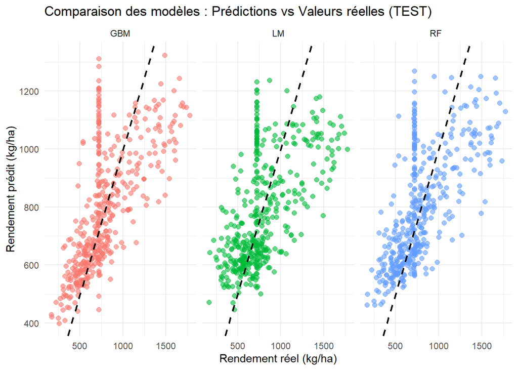

```r
# Préparer les données pour visualisation
comparaison_pred <- tibble(
  Réel = test_data$rendement_kg_ha,
  LM = pred_lm,
  RF = pred_rf,
  GBM = pred_gbm
) %>%
  pivot_longer(
    cols = -Réel,
    names_to = "Modèle",
    values_to = "Prédit"
  )

# Graphique comparatif
plot_compare <- comparaison_pred %>%
  ggplot(aes(x = Réel, y = Prédit, color = Modèle)) +
  geom_point(alpha = 0.6, size = 2) +
  geom_abline(slope = 1, intercept = 0, linetype = "dashed", color = "black", size = 0.8) +
  facet_wrap(~Modèle, nrow = 1) +
  labs(
    title = "Comparaison des modèles : Prédictions vs Valeurs réelles (TEST)",
    x = "Rendement réel (kg/ha)",
    y = "Rendement prédit (kg/ha)"
  ) +
  theme_minimal() +
  theme(legend.position = "none")
print(plot_compare)
```

*Observation :* Plus les points se rapprochent de la ligne diagonale noire, meilleure est la prédiction. Un écart important indique un biais ou une mauvaise généralisation du modèle.

### 7.4.4 6.4.4. Distribution des résidus

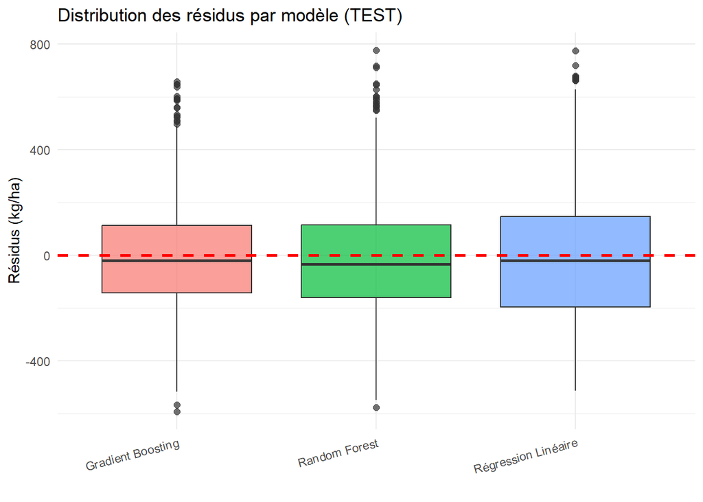

```r
# Calculer les résidus
residus_df <- tibble(
  Modèle = c(
    rep("Régression Linéaire", length(test_data$rendement_kg_ha)),
    rep("Random Forest", length(test_data$rendement_kg_ha)),
    rep("Gradient Boosting", length(test_data$rendement_kg_ha))
  ),
  Résidus = c(
    test_data$rendement_kg_ha - pred_lm,
    test_data$rendement_kg_ha - pred_rf,
    test_data$rendement_kg_ha - pred_gbm
  )
)

# Boxplot des résidus
plot_residus <- residus_df %>%
  ggplot(aes(x = Modèle, y = Résidus, fill = Modèle)) +
  geom_boxplot(alpha = 0.7, outlier.size = 2) +
  geom_hline(yintercept = 0, linetype = "dashed", color = "red", size = 1) +
  labs(
    title = "Distribution des résidus par modèle (TEST)",
    y = "Résidus (kg/ha)",
    x = ""
  ) +
  theme_minimal() +
  theme(legend.position = "none", axis.text.x = element_text(angle = 15, hjust = 1))

print(plot_residus)
```

```r
# Statistiques des résidus
cat("\nSTATISTIQUES DES RÉSIDUS\n")
```

```
##
## STATISTIQUES DES RÉSIDUS
```

```r
residus_df %>%
  group_by(Modèle) %>%
  summarise(
    Moyenne = round(mean(Résidus), 2),
    Médiane = round(median(Résidus), 2),
    Écart_type = round(sd(Résidus), 2),
    Min = round(min(Résidus), 2),
    Max = round(max(Résidus), 2),
    .groups = "drop"
  ) %>%
  print()
```

```
## # A tibble: 3 × 6
##   Modèle              Moyenne Médiane Écart_type   Min   Max
##   <chr>                 <dbl>   <dbl>      <dbl> <dbl> <dbl>
## 1 Gradient Boosting     -2.16   -20.5       234. -591.  657.
## 2 Random Forest         -4.69   -34.1       238. -577.  776.
## 3 Régression Linéaire    4.89   -19.6       261. -512.  774.
```

*Observation :* Idéalement, les résidus doivent être centrés autour de zéro avec une distribution symétrique. Une distribution asymétrique ou biaisée suggère un problème de modélisation.

### 7.4.5 6.4.5. Récapitulatif et recommandations

```r
cat("\n\n")
```

```r
cat("═════════════════════════════════════════════════════════════\n")
```

```
## ═════════════════════════════════════════════════════════════
```

```r
cat("CONCLUSION - COMPARAISON DES MODÈLES\n")
```

```
## CONCLUSION - COMPARAISON DES MODÈLES
```

```r
cat("═════════════════════════════════════════════════════════════\n\n")
```

```
## ═════════════════════════════════════════════════════════════
```

```r
# Afficher le tableau final
cat("Tableau récapitulatif :\n")
```

```
## Tableau récapitulatif :
```

```r
print(resultats_eval)
```

```
## # A tibble: 3 × 4
##   Modèle               RMSE   MAE    R2
##   <chr>               <dbl> <dbl> <dbl>
## 1 Régression Linéaire  261.  204. 0.347
## 2 Random Forest        238.  184. 0.454
## 3 Gradient Boosting    234.  176. 0.474
```

```r
cat("\n\n💡 RECOMMANDATIONS\n")
```

```
##
##
## 💡 RECOMMANDATIONS
```

```r
cat("═════════════════\n\n")
```

```
## ═════════════════
```

```r
if (meilleur$Modèle == "Régression Linéaire") {
  cat("✓ La Régression Linéaire est le modèle optimal.\n")
  cat("✓ Avantages :\n")
  cat("  • Interprétabilité maximale des coefficients\n")
  cat("  • Faible complexité, bon pour la généralisation\n")
  cat("  • Hypothèses statistiques bien établies\n\n")
  cat("✓ Utilisation : Recommandée pour les prédictions opérationnelles\n")
  cat("  et les rapports décisionnels nécessitant une explicabilité.\n")

} else if (meilleur$Modèle == "Random Forest") {
  cat("✓ Le Random Forest est le meilleur prédicteur.\n")
  cat("✓ Avantages :\n")
  cat("  • Capture les non-linéarités et interactions\n")
  cat("  • Robuste aux outliers et aux données manquantes\n")
  cat("  • Importance des variables automatique\n\n")
  cat("✓ Utilisation : Recommandé pour les prédictions précises\n")
  cat("  et l'identification des variables clés.\n")

} else if (meilleur$Modèle == "Gradient Boosting") {
  cat("✓ Le Gradient Boosting offre la meilleure performance.\n")
  cat("✓ Avantages :\n")
  cat("  • Excellent compromis prédiction-généralisation\n")
  cat("  • Ensemble robuste et stable\n")
  cat("  • Très efficace sur données complexes\n\n")
  cat("✓ Utilisation : Recommandé pour les prédictions en production\n")
  cat("  et les analyses prédictives avancées.\n")
}
```

```
## ✓ Le Gradient Boosting offre la meilleure performance.
## ✓ Avantages :
##   • Excellent compromis prédiction-généralisation
##   • Ensemble robuste et stable
##   • Très efficace sur données complexes
##
## ✓ Utilisation : Recommandé pour les prédictions en production
##   et les analyses prédictives avancées.
```

```r
cat("\n\n📊 PROCHAINES ÉTAPES\n")
```

```
##
##
## 📊 PROCHAINES ÉTAPES
```

```r
cat("====================\n\n")
cat("1. Déployer le meilleur modèle (", meilleur$Modèle, ") en production\n", sep = "")
```

```
## 1. Déployer le meilleur modèle (Gradient Boosting) en production
```

```r
cat("2. Valider sur de nouvelles données en 2025\n")
```

```
## 2. Valider sur de nouvelles données en 2025
```

```r
cat("3. Mettre en place une stratégie de drift monitoring\n")
```

```
## 3. Mettre en place une stratégie de drift monitoring
```

```r
cat("4. Intégrer les recommandations agronomiques dans les programmes de formation\n")
```

```
## 4. Intégrer les recommandations agronomiques dans les programmes de formation
```

# 8 7. Recommandations

## 8.1 *Synthèse des résultats*

Cette analyse complète du secteur agricole de l’Extrême-Nord du Cameroun a permis :

## 8.2 *Recommandations opérationnelles*

  Ce projet de Data Science appliquée démontre la faisabilité et l’utilité d’une approche intégrée combinant rigueur statistique et machine learning pour l’aide à la décision agricole en contexte camerounais.